# ANCOVA in Vocabulario Não Ensinado (Vocabulario Não Ensinado)

Geiser C. Challco geiser@alumni.usp.br

- Descriptive Statistics of Initial Data
- ANCOVA and Pairwise for one factor: **grupo**
  - Without remove non-normal data
  - Computing ANCOVA and PairWise After removing non-normal data (OK)
    - Plots for ancova
    - Checking linearity assumption
    - Checking normality and homogeneity
- ANCOVA and Pairwise for two factors **grupo:Sexo**
  - Without remove non-normal data
  - Computing ANCOVA and PairWise After removing non-normal data (OK)
    - Plots for ancova
    - Checking linearity assumption
    - Checking normality and homogeneity
- ANCOVA and Pairwise for two factors **grupo:Zona**
  - Without remove non-normal data
  - Computing ANCOVA and PairWise After removing non-normal data (OK)
    - Plots for ancova
    - Checking linearity assumption
    - Checking normality and homogeneity
- ANCOVA and Pairwise for two factors **grupo:Cor.Raca**
  - Without remove non-normal data
  - Computing ANCOVA and PairWise After removing non-normal data (OK)
    - Plots for ancova
    - Checking linearity assumption
    - Checking normality and homogeneity
- ANCOVA and Pairwise for two factors **grupo:vocab.non.teach.quintile**
  - Without remove non-normal data
  - Computing ANCOVA and PairWise After removing non-normal data (OK)
    - Plots for ancova
    - Checking linearity assumption
    - Checking normality and homogeneity
- Summary of Results
  - Descriptive Statistics
  - ANCOVA Table Comparison
  - PairWise Table Comparison
  - EMMS Table Comparison

**NOTE**:

- Teste ANCOVA para determinar se houve diferenças significativas no Vocabulario Não Ensinado (medido usando pre- e pos-testes).
- ANCOVA test to determine whether there were significant differences in Vocabulario Não Ensinado (measured using pre- and post-tests).

# Descriptive Statistics of Initial Data

```r
df <- get.descriptives(dat, c(dv.pre, dv.pos), c("grupo"),
                       include.global = T, symmetry.test = T, normality.test = F)
df <- plyr::rbind.fill(
  df, do.call(plyr::rbind.fill, lapply(lfatores2, FUN = function(f) {
    if (nrow(dat) > 0 && sum(!is.na(unique(dat[[f]]))) > 1)
      get.descriptives(dat, c(dv.pre,dv.pos), c("grupo", f),
                       symmetry.test = T, normality.test = F)
    }))
)
(df <- df[,c(fatores1[fatores1 %in% colnames(df)],"variable",
             colnames(df)[!colnames(df) %in% c(fatores1,"variable")])])
```

```
##           grupo Sexo   Zona Cor.Raca vocab.non.teach.quintile            variable   n   mean median min max
## 1      Controle <NA>   <NA>     <NA>                     <NA> vocab.non.teach.pre 118 26.424   28.0   8  37
## 2  Experimental <NA>   <NA>     <NA>                     <NA> vocab.non.teach.pre 171 25.959   27.0   8  37
## 3          <NA> <NA>   <NA>     <NA>                     <NA> vocab.non.teach.pre 289 26.149   27.0   8  37
## 4      Controle <NA>   <NA>     <NA>                     <NA> vocab.non.teach.pos 118 27.136   29.0   7  41
## 5  Experimental <NA>   <NA>     <NA>                     <NA> vocab.non.teach.pos 171 26.105   28.0   1  37
## 6          <NA> <NA>   <NA>     <NA>                     <NA> vocab.non.teach.pos 289 26.526   28.0   1  41
## 7      Controle    F   <NA>     <NA>                     <NA> vocab.non.teach.pre  56 26.607   28.0  12  37
## 8      Controle    M   <NA>     <NA>                     <NA> vocab.non.teach.pre  62 26.258   28.0   8  35
## 9  Experimental    F   <NA>     <NA>                     <NA> vocab.non.teach.pre  86 25.674   27.0  10  37
## 10 Experimental    M   <NA>     <NA>                     <NA> vocab.non.teach.pre  85 26.247   26.0   8  37
## 11     Controle    F   <NA>     <NA>                     <NA> vocab.non.teach.pos  56 27.446   28.5  10  35
## 12     Controle    M   <NA>     <NA>                     <NA> vocab.non.teach.pos  62 26.855   29.0   7  41
## 13 Experimental    F   <NA>     <NA>                     <NA> vocab.non.teach.pos  86 26.523   28.0  10  37
## 14 Experimental    M   <NA>     <NA>                     <NA> vocab.non.teach.pos  85 25.682   28.0   1  37
```

[output cut: 98 more lines]

| grupo | Sexo | Zona | Cor.Raca | vocab.non.teach.quintile | variable | n | mean | median | min | max | sd | se | ci | iqr | symmetry | skewness | kurtosis |
| --- | --- | --- | --- | --- | --- | --- | --- | --- | --- | --- | --- | --- | --- | --- | --- | --- | --- |
| Controle |  |  |  |  | vocab.non.teach.pre | 118 | 26.424 | 28.0 | 8 | 37 | 6.111 | 0.563 | 1.114 | 9.00 | NO | -0.838 | 0.351 |
| Experimental |  |  |  |  | vocab.non.teach.pre | 171 | 25.959 | 27.0 | 8 | 37 | 6.009 | 0.460 | 0.907 | 7.00 | NO | -0.703 | 0.298 |
|  |  |  |  |  | vocab.non.teach.pre | 289 | 26.149 | 27.0 | 8 | 37 | 6.045 | 0.356 | 0.700 | 8.00 | NO | -0.760 | 0.331 |
| Controle |  |  |  |  | vocab.non.teach.pos | 118 | 27.136 | 29.0 | 7 | 41 | 6.457 | 0.594 | 1.177 | 8.00 | NO | -0.890 | 0.402 |
| Experimental |  |  |  |  | vocab.non.teach.pos | 171 | 26.105 | 28.0 | 1 | 37 | 6.923 | 0.529 | 1.045 | 9.00 | NO | -1.037 | 1.001 |
|  |  |  |  |  | vocab.non.teach.pos | 289 | 26.526 | 28.0 | 1 | 41 | 6.744 | 0.397 | 0.781 | 8.00 | NO | -0.997 | 0.878 |
| Controle | F |  |  |  | vocab.non.teach.pre | 56 | 26.607 | 28.0 | 12 | 37 | 5.745 | 0.768 | 1.539 | 9.00 | NO | -0.637 | -0.145 |
| Controle | M |  |  |  | vocab.non.teach.pre | 62 | 26.258 | 28.0 | 8 | 35 | 6.465 | 0.821 | 1.642 | 8.50 | NO | -0.927 | 0.425 |
| Experimental | F |  |  |  | vocab.non.teach.pre | 86 | 25.674 | 27.0 | 10 | 37 | 6.085 | 0.656 | 1.305 | 7.75 | NO | -0.695 | -0.080 |
| Experimental | M |  |  |  | vocab.non.teach.pre | 85 | 26.247 | 26.0 | 8 | 37 | 5.954 | 0.646 | 1.284 | 6.00 | NO | -0.697 | 0.626 |
| Controle | F |  |  |  | vocab.non.teach.pos | 56 | 27.446 | 28.5 | 10 | 35 | 5.849 | 0.782 | 1.566 | 8.25 | NO | -0.885 | 0.219 |
| Controle | M |  |  |  | vocab.non.teach.pos | 62 | 26.855 | 29.0 | 7 | 41 | 6.996 | 0.889 | 1.777 | 8.75 | NO | -0.828 | 0.209 |
| Experimental | F |  |  |  | vocab.non.teach.pos | 86 | 26.523 | 28.0 | 10 | 37 | 6.302 | 0.680 | 1.351 | 9.00 | NO | -0.551 | -0.559 |
| Experimental | M |  |  |  | vocab.non.teach.pos | 85 | 25.682 | 28.0 | 1 | 37 | 7.514 | 0.815 | 1.621 | 7.00 | NO | -1.253 | 1.339 |
| Controle |  | Rural |  |  | vocab.non.teach.pre | 41 | 25.976 | 26.0 | 13 | 36 | 5.106 | 0.797 | 1.612 | 7.00 | YES | -0.380 | -0.084 |
| Controle |  | Urbana |  |  | vocab.non.teach.pre | 18 | 27.389 | 29.0 | 10 | 35 | 6.213 | 1.464 | 3.090 | 5.50 | NO | -1.343 | 1.127 |
| Controle |  |  |  |  | vocab.non.teach.pre | 59 | 26.441 | 28.0 | 8 | 37 | 6.752 | 0.879 | 1.760 | 9.50 | NO | -0.844 | 0.050 |
| Experimental |  | Rural |  |  | vocab.non.teach.pre | 61 | 25.066 | 26.0 | 8 | 36 | 6.549 | 0.839 | 1.677 | 9.00 | NO | -0.557 | -0.133 |
| Experimental |  | Urbana |  |  | vocab.non.teach.pre | 43 | 26.093 | 28.0 | 10 | 37 | 6.952 | 1.060 | 2.139 | 9.00 | NO | -0.645 | -0.534 |
| Experimental |  |  |  |  | vocab.non.teach.pre | 67 | 26.687 | 27.0 | 10 | 37 | 4.688 | 0.573 | 1.143 | 6.50 | NO | -0.622 | 1.084 |
| Controle |  | Rural |  |  | vocab.non.teach.pos | 41 | 28.341 | 30.0 | 10 | 41 | 6.227 | 0.973 | 1.966 | 9.00 | NO | -0.852 | 0.565 |
| Controle |  | Urbana |  |  | vocab.non.teach.pos | 18 | 26.556 | 28.0 | 7 | 35 | 8.290 | 1.954 | 4.123 | 9.25 | NO | -1.074 | 0.122 |
| Controle |  |  |  |  | vocab.non.teach.pos | 59 | 26.475 | 27.0 | 13 | 35 | 5.969 | 0.777 | 1.556 | 8.00 | NO | -0.664 | -0.543 |
| Experimental |  | Rural |  |  | vocab.non.teach.pos | 61 | 26.115 | 28.0 | 1 | 37 | 7.225 | 0.925 | 1.850 | 9.00 | NO | -1.206 | 1.348 |
| Experimental |  | Urbana |  |  | vocab.non.teach.pos | 43 | 26.651 | 28.0 | 11 | 36 | 6.309 | 0.962 | 1.942 | 8.00 | NO | -0.698 | -0.208 |
| Experimental |  |  |  |  | vocab.non.teach.pos | 67 | 25.746 | 27.0 | 2 | 37 | 7.095 | 0.867 | 1.731 | 8.50 | NO | -0.952 | 0.757 |
| Controle |  |  | Branca |  | vocab.non.teach.pre | 7 | 27.429 | 28.0 | 22 | 32 | 3.047 | 1.152 | 2.818 | 2.00 | YES | -0.319 | -0.820 |
| Controle |  |  | Indígena |  | vocab.non.teach.pre | 2 | 26.500 | 26.5 | 19 | 34 | 10.607 | 7.500 | 95.297 | 7.50 | few data | 0.000 | 0.000 |
| Controle |  |  | Parda |  | vocab.non.teach.pre | 44 | 25.227 | 27.0 | 8 | 33 | 6.171 | 0.930 | 1.876 | 8.00 | NO | -1.029 | 0.498 |
| Controle |  |  |  |  | vocab.non.teach.pre | 65 | 27.123 | 29.0 | 10 | 37 | 6.201 | 0.769 | 1.537 | 9.00 | NO | -0.728 | -0.091 |
| Experimental |  |  | Branca |  | vocab.non.teach.pre | 13 | 28.462 | 30.0 | 17 | 34 | 5.395 | 1.496 | 3.260 | 9.00 | NO | -0.743 | -0.815 |
| Experimental |  |  | Indígena |  | vocab.non.teach.pre | 3 | 25.333 | 25.0 | 22 | 29 | 3.512 | 2.028 | 8.724 | 3.50 | few data | 0.000 | 0.000 |
| Experimental |  |  | Parda |  | vocab.non.teach.pre | 52 | 23.962 | 25.5 | 8 | 35 | 6.976 | 0.967 | 1.942 | 11.00 | YES | -0.454 | -0.688 |
| Experimental |  |  |  |  | vocab.non.teach.pre | 103 | 26.670 | 27.0 | 8 | 37 | 5.369 | 0.529 | 1.049 | 7.00 | NO | -0.650 | 0.784 |
| Controle |  |  | Branca |  | vocab.non.teach.pos | 7 | 31.286 | 31.0 | 29 | 33 | 1.704 | 0.644 | 1.576 | 3.00 | YES | -0.032 | -2.007 |
| Controle |  |  | Indígena |  | vocab.non.teach.pos | 2 | 26.500 | 26.5 | 18 | 35 | 12.021 | 8.500 | 108.003 | 8.50 | few data | 0.000 | 0.000 |
| Controle |  |  | Parda |  | vocab.non.teach.pos | 44 | 26.023 | 27.0 | 10 | 35 | 6.732 | 1.015 | 2.047 | 11.25 | YES | -0.458 | -0.864 |
| Controle |  |  |  |  | vocab.non.teach.pos | 65 | 27.462 | 29.0 | 7 | 41 | 6.354 | 0.788 | 1.575 | 8.00 | NO | -1.110 | 1.439 |
| Experimental |  |  | Branca |  | vocab.non.teach.pos | 13 | 29.231 | 31.0 | 12 | 37 | 6.444 | 1.787 | 3.894 | 4.00 | NO | -1.345 | 1.297 |
| Experimental |  |  | Indígena |  | vocab.non.teach.pos | 3 | 27.000 | 27.0 | 26 | 28 | 1.000 | 0.577 | 2.484 | 1.00 | few data | 0.000 | 0.000 |
| Experimental |  |  | Parda |  | vocab.non.teach.pos | 52 | 24.077 | 25.5 | 1 | 37 | 8.726 | 1.210 | 2.429 | 13.50 | NO | -0.704 | -0.258 |
| Experimental |  |  |  |  | vocab.non.teach.pos | 103 | 26.709 | 28.0 | 7 | 36 | 5.759 | 0.567 | 1.126 | 8.00 | NO | -0.863 | 0.672 |
| Controle |  |  |  | 1st quintile | vocab.non.teach.pre | 5 | 10.400 | 10.0 | 8 | 13 | 2.074 | 0.927 | 2.575 | 3.00 | YES | 0.113 | -2.034 |
| Controle |  |  |  | 2nd quintile | vocab.non.teach.pre | 10 | 16.900 | 17.5 | 14 | 19 | 2.025 | 0.640 | 1.448 | 3.50 | YES | -0.312 | -1.713 |
| Controle |  |  |  | 3rd quintile | vocab.non.teach.pre | 25 | 22.240 | 22.0 | 20 | 24 | 1.268 | 0.254 | 0.523 | 2.00 | YES | 0.037 | -1.129 |
| Controle |  |  |  | 4th quintile | vocab.non.teach.pre | 37 | 27.541 | 28.0 | 25 | 29 | 1.464 | 0.241 | 0.488 | 3.00 | YES | -0.491 | -1.232 |
| Controle |  |  |  | 5th quintile | vocab.non.teach.pre | 41 | 32.244 | 32.0 | 30 | 37 | 1.841 | 0.288 | 0.581 | 2.00 | NO | 0.611 | -0.458 |
| Experimental |  |  |  | 1st quintile | vocab.non.teach.pre | 8 | 10.625 | 10.5 | 8 | 13 | 1.996 | 0.706 | 1.668 | 2.75 | YES | -0.114 | -1.719 |
| Experimental |  |  |  | 2nd quintile | vocab.non.teach.pre | 16 | 17.438 | 17.5 | 15 | 19 | 1.548 | 0.387 | 0.825 | 2.25 | YES | -0.396 | -1.407 |
| Experimental |  |  |  | 3rd quintile | vocab.non.teach.pre | 36 | 22.278 | 23.0 | 20 | 24 | 1.466 | 0.244 | 0.496 | 2.25 | YES | -0.313 | -1.422 |
| Experimental |  |  |  | 4th quintile | vocab.non.teach.pre | 58 | 26.966 | 27.0 | 25 | 29 | 1.438 | 0.189 | 0.378 | 2.00 | YES | 0.024 | -1.414 |
| Experimental |  |  |  | 5th quintile | vocab.non.teach.pre | 53 | 32.245 | 32.0 | 30 | 37 | 1.950 | 0.268 | 0.538 | 3.00 | NO | 0.607 | -0.571 |
| Controle |  |  |  | 1st quintile | vocab.non.teach.pos | 5 | 15.600 | 16.0 | 9 | 26 | 6.804 | 3.043 | 8.449 | 7.00 | YES | 0.422 | -1.639 |
| Controle |  |  |  | 2nd quintile | vocab.non.teach.pos | 10 | 19.000 | 18.5 | 13 | 29 | 5.011 | 1.585 | 3.585 | 6.75 | NO | 0.539 | -0.896 |
| Controle |  |  |  | 3rd quintile | vocab.non.teach.pos | 25 | 24.360 | 24.0 | 13 | 34 | 5.098 | 1.020 | 2.104 | 7.00 | YES | -0.205 | -0.232 |
| Controle |  |  |  | 4th quintile | vocab.non.teach.pos | 37 | 28.865 | 30.0 | 7 | 41 | 5.564 | 0.915 | 1.855 | 5.00 | NO | -1.537 | 4.679 |
| Controle |  |  |  | 5th quintile | vocab.non.teach.pos | 41 | 30.659 | 32.0 | 20 | 35 | 3.838 | 0.599 | 1.211 | 4.00 | NO | -1.039 | 0.028 |
| Experimental |  |  |  | 1st quintile | vocab.non.teach.pos | 8 | 17.750 | 17.0 | 7 | 30 | 6.861 | 2.426 | 5.736 | 4.25 | YES | 0.213 | -0.871 |
| Experimental |  |  |  | 2nd quintile | vocab.non.teach.pos | 16 | 18.062 | 18.5 | 11 | 31 | 6.137 | 1.534 | 3.270 | 9.25 | YES | 0.411 | -1.007 |
| Experimental |  |  |  | 3rd quintile | vocab.non.teach.pos | 36 | 24.778 | 25.5 | 2 | 35 | 6.225 | 1.037 | 2.106 | 7.00 | NO | -1.192 | 2.759 |
| Experimental |  |  |  | 4th quintile | vocab.non.teach.pos | 58 | 25.448 | 27.0 | 1 | 33 | 6.213 | 0.816 | 1.634 | 7.00 | NO | -1.543 | 3.007 |
| Experimental |  |  |  | 5th quintile | vocab.non.teach.pos | 53 | 31.415 | 31.0 | 24 | 37 | 3.165 | 0.435 | 0.872 | 4.00 | YES | -0.350 | -0.505 |

# ANCOVA and Pairwise for one factor: **grupo**

## Without remove non-normal data

```r
pdat = remove_group_data(dat[!is.na(dat[["grupo"]]),], "vocab.non.teach.pos", "grupo")

pdat.long <- rbind(pdat[,c("id","grupo")], pdat[,c("id","grupo")])
pdat.long[["time"]] <- c(rep("pre", nrow(pdat)), rep("pos", nrow(pdat)))
pdat.long[["time"]] <- factor(pdat.long[["time"]], c("pre","pos"))
pdat.long[["vocab.non.teach"]] <- c(pdat[["vocab.non.teach.pre"]], pdat[["vocab.non.teach.pos"]])

aov = anova_test(pdat, vocab.non.teach.pos ~ vocab.non.teach.pre + grupo)
laov[["grupo"]] <- get_anova_table(aov)
```

```r
pwc <- emmeans_test(pdat, vocab.non.teach.pos ~ grupo, covariate = vocab.non.teach.pre,
                    p.adjust.method = "bonferroni")
```

```r
pwc.long <- emmeans_test(dplyr::group_by_at(pdat.long, "grupo"),
                          vocab.non.teach ~ time,
                          p.adjust.method = "bonferroni")
lpwc[["grupo"]] <- plyr::rbind.fill(pwc, pwc.long)
```

```r
ds <- get.descriptives(pdat, "vocab.non.teach.pos", "grupo", covar = "vocab.non.teach.pre")
ds <- merge(ds[ds$variable != "vocab.non.teach.pre",],
            ds[ds$variable == "vocab.non.teach.pre", !colnames(ds) %in% c("variable")],
            by = "grupo", all.x = T, suffixes = c("", ".vocab.non.teach.pre"))
ds <- merge(get_emmeans(pwc), ds, by = "grupo", suffixes = c(".emms", ""))
ds <- ds[,c("grupo","n","mean.vocab.non.teach.pre","se.vocab.non.teach.pre","mean","se","emmean","se.emms")]

colnames(ds) <- c("grupo", "N", paste0(c("M","SE")," (pre)"),
                  paste0(c("M","SE"), " (unadj)"), paste0(c("M", "SE"), " (adj)"))

lemms[["grupo"]] <- ds
```

## Computing ANCOVA and PairWise After removing non-normal data (OK)

```r
wdat = pdat

res = residuals(lm(vocab.non.teach.pos ~ vocab.non.teach.pre + grupo, data = wdat))
non.normal = getNonNormal(res, wdat$id, plimit = 0.05)

wdat = wdat[!wdat$id %in% non.normal,]

wdat.long <- rbind(wdat[,c("id","grupo")], wdat[,c("id","grupo")])
wdat.long[["time"]] <- c(rep("pre", nrow(wdat)), rep("pos", nrow(wdat)))
wdat.long[["time"]] <- factor(wdat.long[["time"]], c("pre","pos"))
wdat.long[["vocab.non.teach"]] <- c(wdat[["vocab.non.teach.pre"]], wdat[["vocab.non.teach.pos"]])

ldat[["grupo"]] = wdat

(non.normal)
```

```
## [1] "P1139" "P1113" "P2304" "P1112" "P1129" "P3265" "P3260"
```

```r
aov = anova_test(wdat, vocab.non.teach.pos ~ vocab.non.teach.pre + grupo)
laov[["grupo"]] <- merge(get_anova_table(aov), laov[["grupo"]], by="Effect", suffixes = c("","'"))

(df = get_anova_table(aov))
```

```
## ANOVA Table (type II tests)
##
##                Effect DFn DFd       F        p p<.05   ges
## 1 vocab.non.teach.pre   1 279 296.141 9.88e-46     * 0.515
## 2               grupo   1 279   0.579 4.47e-01       0.002
```

| Effect | DFn | DFd | F | p | p<.05 | ges |
| --- | --- | --- | --- | --- | --- | --- |
| vocab.non.teach.pre | 1 | 279 | 296.141 | 0.000 | * | 0.515 |
| grupo | 1 | 279 | 0.579 | 0.447 |  | 0.002 |

| term | .y. | group1 | group2 | df | statistic | p | p.adj | p.adj.signif |
| --- | --- | --- | --- | --- | --- | --- | --- | --- |
| vocab.non.teach.pre*grupo | vocab.non.teach.pos | Controle | Experimental | 279 | 0.761 | 0.447 | 0.447 | ns |

```r
pwc.long <- emmeans_test(dplyr::group_by_at(wdat.long, "grupo"),
                         vocab.non.teach ~ time,
                         p.adjust.method = "bonferroni")
lpwc[["grupo"]] <- merge(plyr::rbind.fill(pwc, pwc.long), lpwc[["grupo"]], by=c("grupo","term",".y.","group1","group2"), suffixes = c("","'"))
```

| grupo | term | .y. | group1 | group2 | df | statistic | p | p.adj | p.adj.signif |
| --- | --- | --- | --- | --- | --- | --- | --- | --- | --- |
| Controle | time | vocab.non.teach | pre | pos | 560 | -1.093 | 0.275 | 0.275 | ns |
| Experimental | time | vocab.non.teach | pre | pos | 560 | -0.848 | 0.397 | 0.397 | ns |

```r
ds <- get.descriptives(wdat, "vocab.non.teach.pos", "grupo", covar = "vocab.non.teach.pre")
ds <- merge(ds[ds$variable != "vocab.non.teach.pre",],
            ds[ds$variable == "vocab.non.teach.pre", !colnames(ds) %in% c("variable")],
            by = "grupo", all.x = T, suffixes = c("", ".vocab.non.teach.pre"))
ds <- merge(get_emmeans(pwc), ds, by = "grupo", suffixes = c(".emms", ""))
ds <- ds[,c("grupo","n","mean.vocab.non.teach.pre","se.vocab.non.teach.pre","mean","se","emmean","se.emms")]

colnames(ds) <- c("grupo", "N", paste0(c("M","SE")," (pre)"),
                  paste0(c("M","SE"), " (unadj)"), paste0(c("M", "SE"), " (adj)"))

lemms[["grupo"]] <- merge(ds, lemms[["grupo"]], by=c("grupo"), suffixes = c("","'"))
```

| grupo | N | M (pre) | SE (pre) | M (unadj) | SE (unadj) | M (adj) | SE (adj) |
| --- | --- | --- | --- | --- | --- | --- | --- |
| Controle | 117 | 26.436 | 0.567 | 27.308 | 0.574 | 27.154 | 0.399 |
| Experimental | 165 | 26.079 | 0.463 | 26.648 | 0.479 | 26.757 | 0.336 |

### Plots for ancova

```r
plots <- oneWayAncovaPlots(
  wdat, "vocab.non.teach.pos", "grupo", aov, list("grupo"=pwc), addParam = c("mean_se"),
  font.label.size=10, step.increase=0.05, p.label="p.adj",
  subtitle = which(aov$Effect == "grupo"))
```

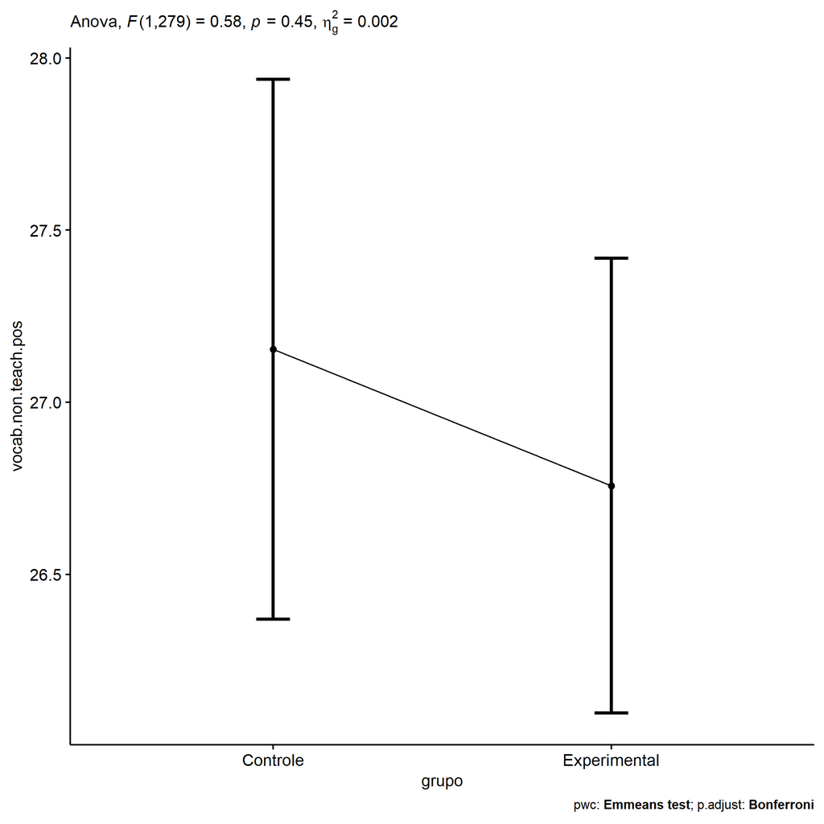

```r
if (!is.null(nrow(plots[["grupo"]]$data)))
  plots[["grupo"]] + ggplot2::scale_color_manual(values = color[["grupo"]])
```

```r
plots <- oneWayAncovaBoxPlots(
  wdat, "vocab.non.teach.pos", "grupo", aov, pwc, covar = "vocab.non.teach.pre",
  theme = "classic", color = color[["grupo"]],
  subtitle = which(aov$Effect == "grupo"))
```

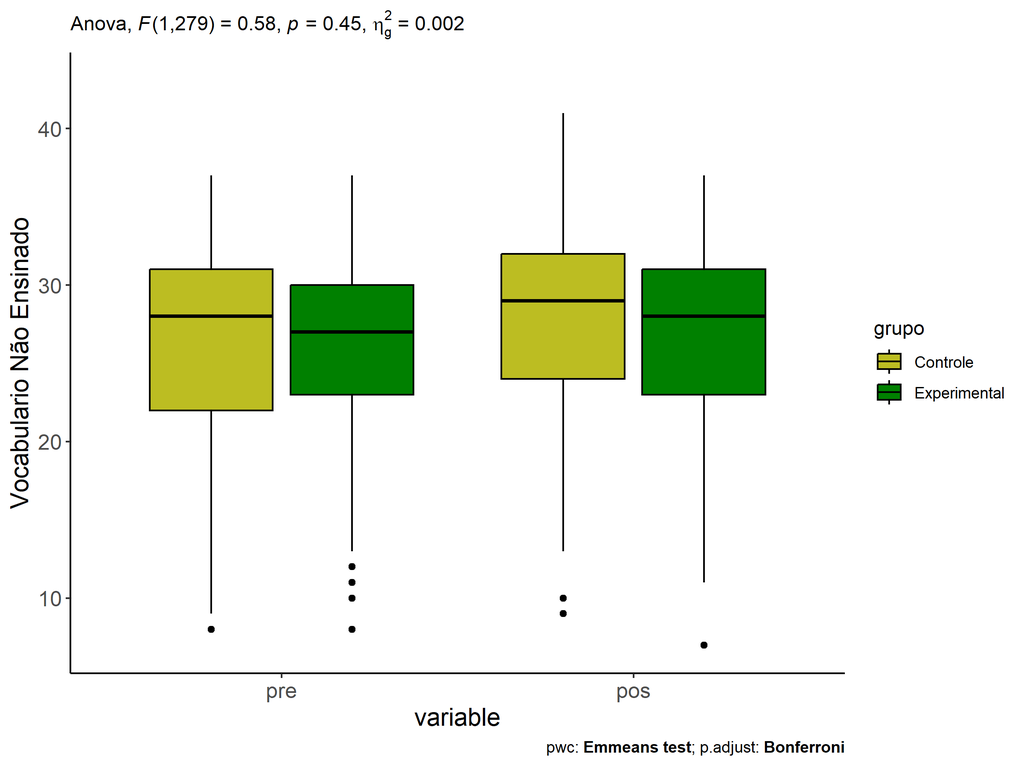

```r
if (length(unique(wdat[["grupo"]])) > 1)
  plots[["grupo"]] + ggplot2::ylab("Vocabulario Não Ensinado") + ggplot2::scale_x_discrete(labels=c('pre', 'pos'))
```

```r
if (length(unique(wdat.long[["grupo"]])) > 1)
  plots <- oneWayAncovaBoxPlots(
    wdat.long, "vocab.non.teach", "grupo", aov, pwc.long, pre.post = "time",
    theme = "classic", color = color$prepost)
```

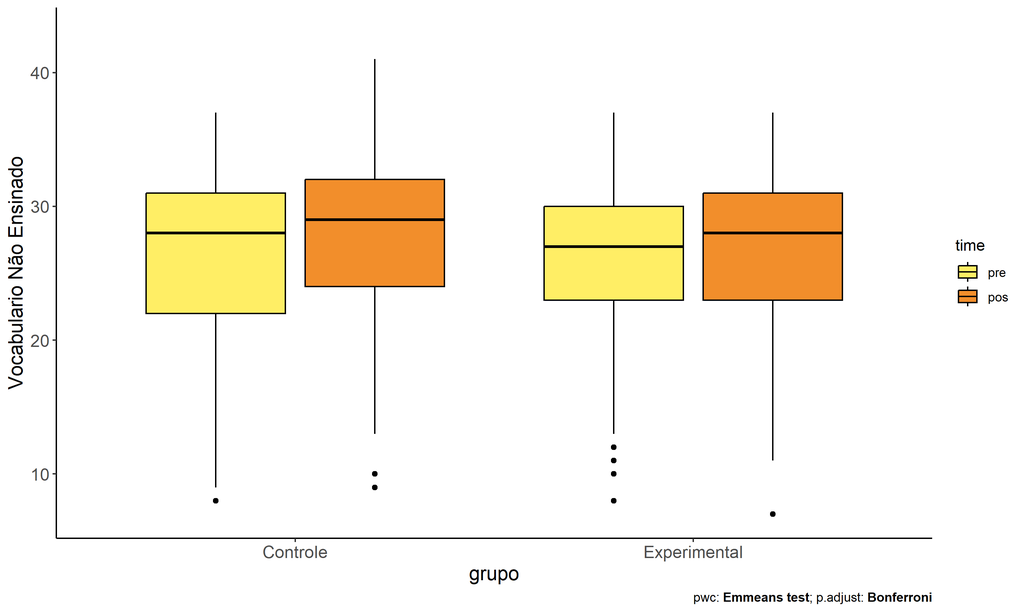

```r
if (length(unique(wdat.long[["grupo"]])) > 1)
  plots[["grupo"]] + ggplot2::ylab("Vocabulario Não Ensinado")
```

### Checking linearity assumption

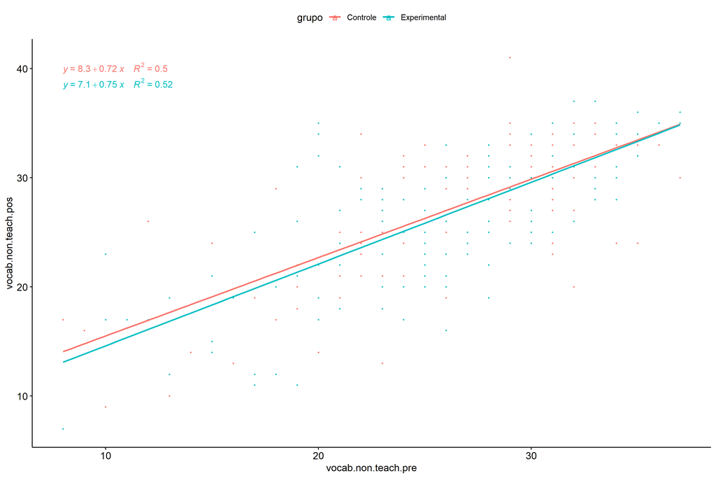

```r
ggscatter(wdat, x = "vocab.non.teach.pre", y = "vocab.non.teach.pos", size = 0.5,
          color = "grupo", add = "reg.line")+
  stat_regline_equation(
    aes(label =  paste(..eq.label.., ..rr.label.., sep = "~~~~"), color = grupo)
  )
```

### Checking normality and homogeneity

```r
res <- augment(lm(vocab.non.teach.pos ~ vocab.non.teach.pre + grupo, data = wdat))
```

```r
shapiro_test(res$.resid)
```

```
## # A tibble: 1 × 3
##   variable   statistic p.value
##   <chr>          <dbl>   <dbl>
## 1 res$.resid     0.991  0.0890
```

```r
levene_test(res, .resid ~ grupo)
```

```
## # A tibble: 1 × 4
##     df1   df2 statistic     p
##   <int> <int>     <dbl> <dbl>
## 1     1   280    0.0955 0.758
```

# ANCOVA and Pairwise for two factors **grupo:Sexo**

## Without remove non-normal data

```r
pdat = remove_group_data(dat[!is.na(dat[["grupo"]]) & !is.na(dat[["Sexo"]]),], "vocab.non.teach.pos", c("grupo","Sexo"))

pdat.long <- rbind(pdat[,c("id","grupo","Sexo")], pdat[,c("id","grupo","Sexo")])
pdat.long[["time"]] <- c(rep("pre", nrow(pdat)), rep("pos", nrow(pdat)))
pdat.long[["time"]] <- factor(pdat.long[["time"]], c("pre","pos"))
pdat.long[["vocab.non.teach"]] <- c(pdat[["vocab.non.teach.pre"]], pdat[["vocab.non.teach.pos"]])

aov = anova_test(pdat, vocab.non.teach.pos ~ vocab.non.teach.pre + grupo*Sexo)
laov[["grupo:Sexo"]] <- get_anova_table(aov)
```

```r
pwcs <- list()
pwcs[["Sexo"]] <- emmeans_test(
  group_by(pdat, grupo), vocab.non.teach.pos ~ Sexo,
  covariate = vocab.non.teach.pre, p.adjust.method = "bonferroni")
pwcs[["grupo"]] <- emmeans_test(
  group_by(pdat, Sexo), vocab.non.teach.pos ~ grupo,
  covariate = vocab.non.teach.pre, p.adjust.method = "bonferroni")

pwc <- plyr::rbind.fill(pwcs[["grupo"]], pwcs[["Sexo"]])
pwc <- pwc[,c("grupo","Sexo", colnames(pwc)[!colnames(pwc) %in% c("grupo","Sexo")])]
```

```r
pwc.long <- emmeans_test(dplyr::group_by_at(pdat.long, c("grupo","Sexo")),
                         vocab.non.teach ~ time,
                         p.adjust.method = "bonferroni")
lpwc[["grupo:Sexo"]] <- plyr::rbind.fill(pwc, pwc.long)
```

```r
ds <- get.descriptives(pdat, "vocab.non.teach.pos", c("grupo","Sexo"), covar = "vocab.non.teach.pre")
ds <- merge(ds[ds$variable != "vocab.non.teach.pre",],
            ds[ds$variable == "vocab.non.teach.pre", !colnames(ds) %in% c("variable")],
            by = c("grupo","Sexo"), all.x = T, suffixes = c("", ".vocab.non.teach.pre"))
ds <- merge(get_emmeans(pwcs[["grupo"]]), ds, by = c("grupo","Sexo"), suffixes = c(".emms", ""))
ds <- ds[,c("grupo","Sexo","n","mean.vocab.non.teach.pre","se.vocab.non.teach.pre","mean","se","emmean","se.emms")]

colnames(ds) <- c("grupo","Sexo", "N", paste0(c("M","SE")," (pre)"),
                  paste0(c("M","SE"), " (unadj)"), paste0(c("M", "SE"), " (adj)"))

lemms[["grupo:Sexo"]] <- ds
```

## Computing ANCOVA and PairWise After removing non-normal data (OK)

```r
wdat = pdat

res = residuals(lm(vocab.non.teach.pos ~ vocab.non.teach.pre + grupo*Sexo, data = wdat))
non.normal = getNonNormal(res, wdat$id, plimit = 0.05)

wdat = wdat[!wdat$id %in% non.normal,]

wdat.long <- rbind(wdat[,c("id","grupo","Sexo")], wdat[,c("id","grupo","Sexo")])
wdat.long[["time"]] <- c(rep("pre", nrow(wdat)), rep("pos", nrow(wdat)))
wdat.long[["time"]] <- factor(wdat.long[["time"]], c("pre","pos"))
wdat.long[["vocab.non.teach"]] <- c(wdat[["vocab.non.teach.pre"]], wdat[["vocab.non.teach.pos"]])


ldat[["grupo:Sexo"]] = wdat

(non.normal)
```

```
##  [1] "P1139" "P1113" "P2304" "P1129" "P1112" "P3260" "P3236" "P2359" "P1165" "P3228" "P1151"
```

```r
aov = anova_test(wdat, vocab.non.teach.pos ~ vocab.non.teach.pre + grupo*Sexo)
laov[["grupo:Sexo"]] <- merge(get_anova_table(aov), laov[["grupo:Sexo"]], by="Effect", suffixes = c("","'"))

(df = get_anova_table(aov))
```

```
## ANOVA Table (type II tests)
##
##                Effect DFn DFd       F        p p<.05   ges
## 1 vocab.non.teach.pre   1 273 298.756 1.00e-45     * 0.523
## 2               grupo   1 273   2.352 1.26e-01       0.009
## 3                Sexo   1 273   1.204 2.74e-01       0.004
## 4          grupo:Sexo   1 273   1.075 3.01e-01       0.004
```

| Effect | DFn | DFd | F | p | p<.05 | ges |
| --- | --- | --- | --- | --- | --- | --- |
| vocab.non.teach.pre | 1 | 273 | 298.756 | 0.000 | * | 0.523 |
| grupo | 1 | 273 | 2.352 | 0.126 |  | 0.009 |
| Sexo | 1 | 273 | 1.204 | 0.274 |  | 0.004 |
| grupo:Sexo | 1 | 273 | 1.075 | 0.301 |  | 0.004 |

```r
pwcs <- list()
pwcs[["Sexo"]] <- emmeans_test(
  group_by(wdat, grupo), vocab.non.teach.pos ~ Sexo,
  covariate = vocab.non.teach.pre, p.adjust.method = "bonferroni")
pwcs[["grupo"]] <- emmeans_test(
  group_by(wdat, Sexo), vocab.non.teach.pos ~ grupo,
  covariate = vocab.non.teach.pre, p.adjust.method = "bonferroni")

pwc <- plyr::rbind.fill(pwcs[["grupo"]], pwcs[["Sexo"]])
pwc <- pwc[,c("grupo","Sexo", colnames(pwc)[!colnames(pwc) %in% c("grupo","Sexo")])]
```

| grupo | Sexo | term | .y. | group1 | group2 | df | statistic | p | p.adj | p.adj.signif |
| --- | --- | --- | --- | --- | --- | --- | --- | --- | --- | --- |
|  | F | vocab.non.teach.pre*grupo | vocab.non.teach.pos | Controle | Experimental | 273 | 0.331 | 0.741 | 0.741 | ns |
|  | M | vocab.non.teach.pre*grupo | vocab.non.teach.pos | Controle | Experimental | 273 | 1.821 | 0.070 | 0.070 | ns |
| Controle |  | vocab.non.teach.pre*Sexo | vocab.non.teach.pos | F | M | 273 | -0.101 | 0.920 | 0.920 | ns |
| Experimental |  | vocab.non.teach.pre*Sexo | vocab.non.teach.pos | F | M | 273 | 1.506 | 0.133 | 0.133 | ns |

```r
pwc.long <- emmeans_test(dplyr::group_by_at(wdat.long, c("grupo","Sexo")),
                         vocab.non.teach ~ time,
                         p.adjust.method = "bonferroni")
lpwc[["grupo:Sexo"]] <- merge(plyr::rbind.fill(pwc, pwc.long), lpwc[["grupo:Sexo"]], by=c("grupo","Sexo","term",".y.","group1","group2"), suffixes = c("","'"))
```

| grupo | Sexo | term | .y. | group1 | group2 | df | statistic | p | p.adj | p.adj.signif |
| --- | --- | --- | --- | --- | --- | --- | --- | --- | --- | --- |
| Controle | F | time | vocab.non.teach | pre | pos | 548 | -0.907 | 0.365 | 0.365 | ns |
| Controle | M | time | vocab.non.teach | pre | pos | 548 | -1.172 | 0.242 | 0.242 | ns |
| Experimental | F | time | vocab.non.teach | pre | pos | 548 | -1.212 | 0.226 | 0.226 | ns |
| Experimental | M | time | vocab.non.teach | pre | pos | 548 | 0.078 | 0.938 | 0.938 | ns |

```r
ds <- get.descriptives(wdat, "vocab.non.teach.pos", c("grupo","Sexo"), covar = "vocab.non.teach.pre")
ds <- merge(ds[ds$variable != "vocab.non.teach.pre",],
            ds[ds$variable == "vocab.non.teach.pre", !colnames(ds) %in% c("variable")],
            by = c("grupo","Sexo"), all.x = T, suffixes = c("", ".vocab.non.teach.pre"))
ds <- merge(get_emmeans(pwcs[["grupo"]]), ds, by = c("grupo","Sexo"), suffixes = c(".emms", ""))
ds <- ds[,c("grupo","Sexo","n","mean.vocab.non.teach.pre","se.vocab.non.teach.pre","mean","se","emmean","se.emms")]

colnames(ds) <- c("grupo","Sexo", "N", paste0(c("M","SE")," (pre)"),
                  paste0(c("M","SE"), " (unadj)"), paste0(c("M", "SE"), " (adj)"))

lemms[["grupo:Sexo"]] <- merge(ds, lemms[["grupo:Sexo"]], by=c("grupo","Sexo"), suffixes = c("","'"))
```

| grupo | Sexo | N | M (pre) | SE (pre) | M (unadj) | SE (unadj) | M (adj) | SE (adj) |
| --- | --- | --- | --- | --- | --- | --- | --- | --- |
| Controle | F | 54 | 26.870 | 0.754 | 27.926 | 0.722 | 27.481 | 0.574 |
| Controle | M | 59 | 26.237 | 0.856 | 27.542 | 0.824 | 27.561 | 0.549 |
| Experimental | F | 84 | 25.679 | 0.672 | 26.810 | 0.660 | 27.237 | 0.460 |
| Experimental | M | 81 | 26.481 | 0.636 | 26.407 | 0.713 | 26.247 | 0.468 |

### Plots for ancova

```r
plots <- twoWayAncovaPlots(
  wdat, "vocab.non.teach.pos", c("grupo","Sexo"), aov, pwcs, addParam = c("mean_se"),
  font.label.size=10, step.increase=0.05, p.label="p.adj",
  subtitle = which(aov$Effect == "grupo:Sexo"))
```

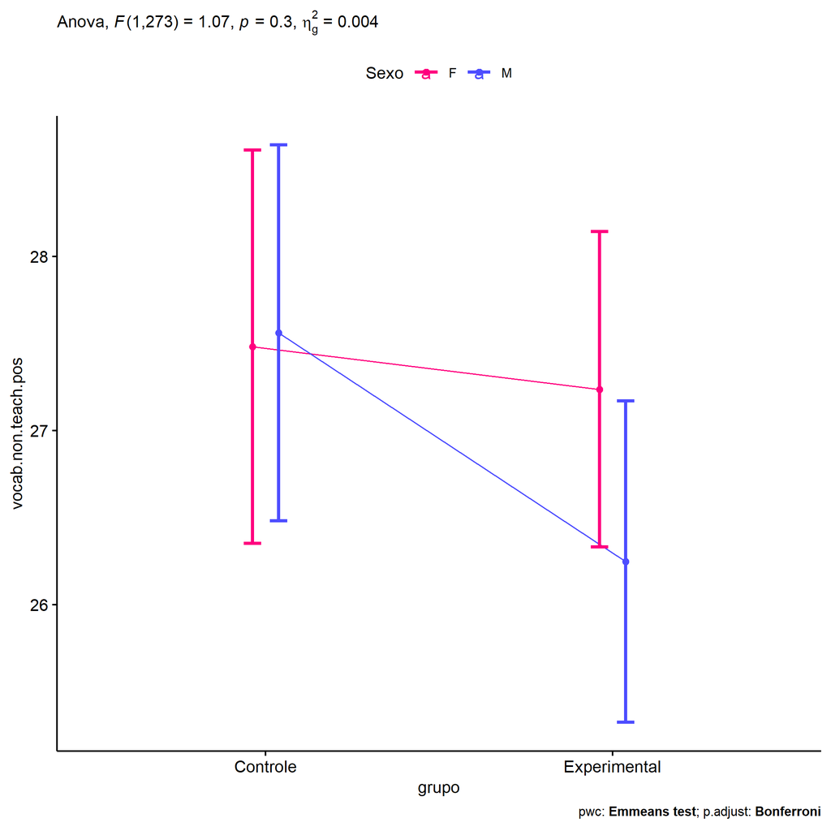

```r
if (!is.null(plots[["grupo"]]))
  plots[["grupo"]] + ggplot2::scale_color_manual(values = color[["Sexo"]])
```

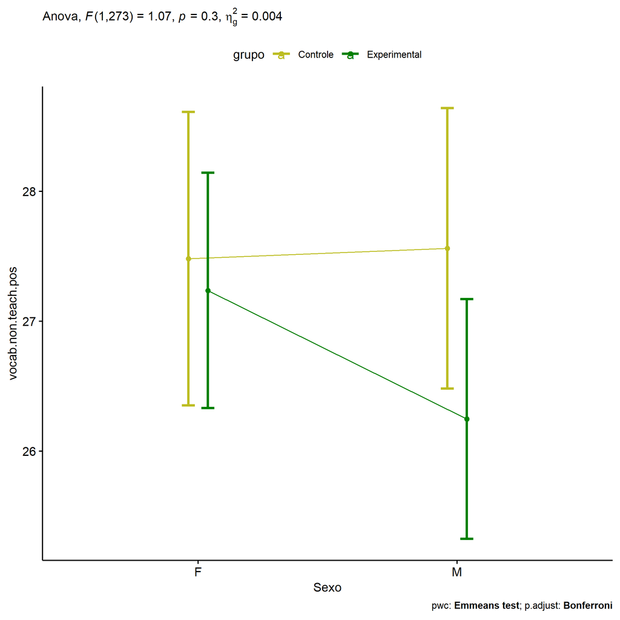

```r
if (!is.null(plots[["Sexo"]]))
  plots[["Sexo"]] + ggplot2::scale_color_manual(values = color[["grupo"]])
```

```r
plots <- twoWayAncovaBoxPlots(
  wdat, "vocab.non.teach.pos", c("grupo","Sexo"), aov, pwcs, covar = "vocab.non.teach.pre",
  theme = "classic", color = color[["grupo:Sexo"]],
  subtitle = which(aov$Effect == "grupo:Sexo"))
```

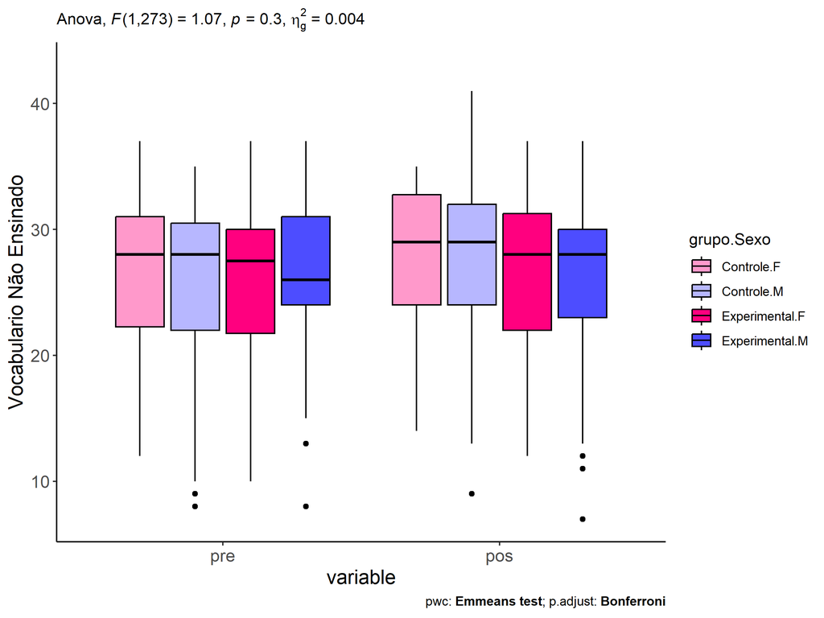

```r
plots[["grupo:Sexo"]] + ggplot2::ylab("Vocabulario Não Ensinado") + ggplot2::scale_x_discrete(labels=c('pre', 'pos'))
```

```r
plots <- twoWayAncovaBoxPlots(
  wdat.long, "vocab.non.teach", c("grupo","Sexo"), aov, pwc.long, pre.post = "time",
  theme = "classic", color = color$prepost)
```

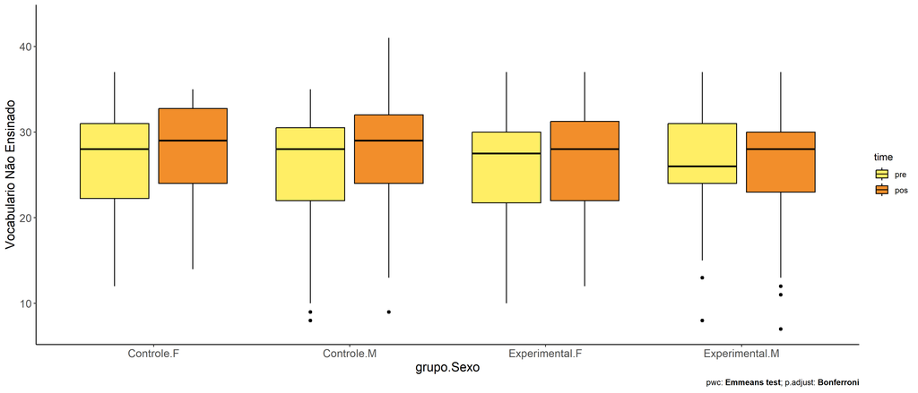

```r
plots[["grupo:Sexo"]] + ggplot2::ylab("Vocabulario Não Ensinado")
```

### Checking linearity assumption

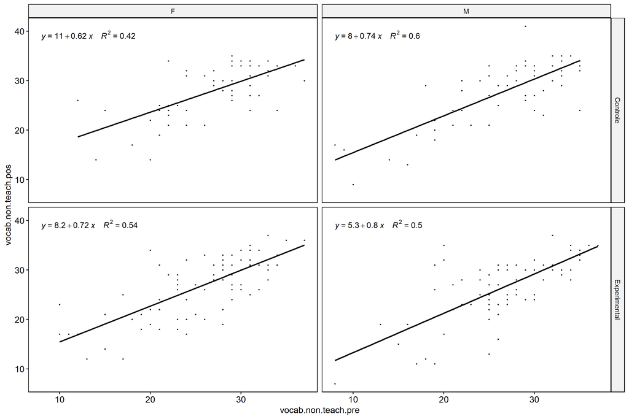

```r
ggscatter(wdat, x = "vocab.non.teach.pre", y = "vocab.non.teach.pos", size = 0.5,
          facet.by = c("grupo","Sexo"), add = "reg.line")+
  stat_regline_equation(
    aes(label =  paste(..eq.label.., ..rr.label.., sep = "~~~~"))
  )
```

### Checking normality and homogeneity

```r
res <- augment(lm(vocab.non.teach.pos ~ vocab.non.teach.pre + grupo*Sexo, data = wdat))
```

```r
shapiro_test(res$.resid)
```

```
## # A tibble: 1 × 3
##   variable   statistic p.value
##   <chr>          <dbl>   <dbl>
## 1 res$.resid     0.991   0.100
```

```r
levene_test(res, .resid ~ grupo*Sexo)
```

```
## # A tibble: 1 × 4
##     df1   df2 statistic     p
##   <int> <int>     <dbl> <dbl>
## 1     3   274     0.163 0.921
```

# ANCOVA and Pairwise for two factors **grupo:Zona**

## Without remove non-normal data

```r
pdat = remove_group_data(dat[!is.na(dat[["grupo"]]) & !is.na(dat[["Zona"]]),], "vocab.non.teach.pos", c("grupo","Zona"))

pdat.long <- rbind(pdat[,c("id","grupo","Zona")], pdat[,c("id","grupo","Zona")])
pdat.long[["time"]] <- c(rep("pre", nrow(pdat)), rep("pos", nrow(pdat)))
pdat.long[["time"]] <- factor(pdat.long[["time"]], c("pre","pos"))
pdat.long[["vocab.non.teach"]] <- c(pdat[["vocab.non.teach.pre"]], pdat[["vocab.non.teach.pos"]])

aov = anova_test(pdat, vocab.non.teach.pos ~ vocab.non.teach.pre + grupo*Zona)
laov[["grupo:Zona"]] <- get_anova_table(aov)
```

```r
pwcs <- list()
pwcs[["Zona"]] <- emmeans_test(
  group_by(pdat, grupo), vocab.non.teach.pos ~ Zona,
  covariate = vocab.non.teach.pre, p.adjust.method = "bonferroni")
pwcs[["grupo"]] <- emmeans_test(
  group_by(pdat, Zona), vocab.non.teach.pos ~ grupo,
  covariate = vocab.non.teach.pre, p.adjust.method = "bonferroni")

pwc <- plyr::rbind.fill(pwcs[["grupo"]], pwcs[["Zona"]])
pwc <- pwc[,c("grupo","Zona", colnames(pwc)[!colnames(pwc) %in% c("grupo","Zona")])]
```

```r
pwc.long <- emmeans_test(dplyr::group_by_at(pdat.long, c("grupo","Zona")),
                         vocab.non.teach ~ time,
                         p.adjust.method = "bonferroni")
lpwc[["grupo:Zona"]] <- plyr::rbind.fill(pwc, pwc.long)
```

```r
ds <- get.descriptives(pdat, "vocab.non.teach.pos", c("grupo","Zona"), covar = "vocab.non.teach.pre")
ds <- merge(ds[ds$variable != "vocab.non.teach.pre",],
            ds[ds$variable == "vocab.non.teach.pre", !colnames(ds) %in% c("variable")],
            by = c("grupo","Zona"), all.x = T, suffixes = c("", ".vocab.non.teach.pre"))
ds <- merge(get_emmeans(pwcs[["grupo"]]), ds, by = c("grupo","Zona"), suffixes = c(".emms", ""))
ds <- ds[,c("grupo","Zona","n","mean.vocab.non.teach.pre","se.vocab.non.teach.pre","mean","se","emmean","se.emms")]

colnames(ds) <- c("grupo","Zona", "N", paste0(c("M","SE")," (pre)"),
                  paste0(c("M","SE"), " (unadj)"), paste0(c("M", "SE"), " (adj)"))

lemms[["grupo:Zona"]] <- ds
```

## Computing ANCOVA and PairWise After removing non-normal data (OK)

```r
wdat = pdat

res = residuals(lm(vocab.non.teach.pos ~ vocab.non.teach.pre + grupo*Zona, data = wdat))
non.normal = getNonNormal(res, wdat$id, plimit = 0.05)

wdat = wdat[!wdat$id %in% non.normal,]

wdat.long <- rbind(wdat[,c("id","grupo","Zona")], wdat[,c("id","grupo","Zona")])
wdat.long[["time"]] <- c(rep("pre", nrow(wdat)), rep("pos", nrow(wdat)))
wdat.long[["time"]] <- factor(wdat.long[["time"]], c("pre","pos"))
wdat.long[["vocab.non.teach"]] <- c(wdat[["vocab.non.teach.pre"]], wdat[["vocab.non.teach.pos"]])


ldat[["grupo:Zona"]] = wdat

(non.normal)
```

```
## [1] "P1139" "P2304"
```

```r
aov = anova_test(wdat, vocab.non.teach.pos ~ vocab.non.teach.pre + grupo*Zona)
laov[["grupo:Zona"]] <- merge(get_anova_table(aov), laov[["grupo:Zona"]], by="Effect", suffixes = c("","'"))

(df = get_anova_table(aov))
```

```
## ANOVA Table (type II tests)
##
##                Effect DFn DFd       F        p p<.05   ges
## 1 vocab.non.teach.pre   1 156 177.008 1.79e-27     * 0.532
## 2               grupo   1 156   1.042 3.09e-01       0.007
## 3                Zona   1 156   1.963 1.63e-01       0.012
## 4          grupo:Zona   1 156   0.534 4.66e-01       0.003
```

| Effect | DFn | DFd | F | p | p<.05 | ges |
| --- | --- | --- | --- | --- | --- | --- |
| vocab.non.teach.pre | 1 | 156 | 177.008 | 0.000 | * | 0.532 |
| grupo | 1 | 156 | 1.042 | 0.309 |  | 0.007 |
| Zona | 1 | 156 | 1.963 | 0.163 |  | 0.012 |
| grupo:Zona | 1 | 156 | 0.534 | 0.466 |  | 0.003 |

```r
pwcs <- list()
pwcs[["Zona"]] <- emmeans_test(
  group_by(wdat, grupo), vocab.non.teach.pos ~ Zona,
  covariate = vocab.non.teach.pre, p.adjust.method = "bonferroni")
pwcs[["grupo"]] <- emmeans_test(
  group_by(wdat, Zona), vocab.non.teach.pos ~ grupo,
  covariate = vocab.non.teach.pre, p.adjust.method = "bonferroni")

pwc <- plyr::rbind.fill(pwcs[["grupo"]], pwcs[["Zona"]])
pwc <- pwc[,c("grupo","Zona", colnames(pwc)[!colnames(pwc) %in% c("grupo","Zona")])]
```

| grupo | Zona | term | .y. | group1 | group2 | df | statistic | p | p.adj | p.adj.signif |
| --- | --- | --- | --- | --- | --- | --- | --- | --- | --- | --- |
|  | Rural | vocab.non.teach.pre*grupo | vocab.non.teach.pos | Controle | Experimental | 156 | 1.255 | 0.211 | 0.211 | ns |
|  | Urbana | vocab.non.teach.pre*grupo | vocab.non.teach.pos | Controle | Experimental | 156 | -0.006 | 0.995 | 0.995 | ns |
| Controle |  | vocab.non.teach.pre*Zona | vocab.non.teach.pos | Rural | Urbana | 156 | 1.400 | 0.164 | 0.164 | ns |
| Experimental |  | vocab.non.teach.pre*Zona | vocab.non.teach.pos | Rural | Urbana | 156 | 0.740 | 0.460 | 0.460 | ns |

```r
pwc.long <- emmeans_test(dplyr::group_by_at(wdat.long, c("grupo","Zona")),
                         vocab.non.teach ~ time,
                         p.adjust.method = "bonferroni")
lpwc[["grupo:Zona"]] <- merge(plyr::rbind.fill(pwc, pwc.long), lpwc[["grupo:Zona"]], by=c("grupo","Zona","term",".y.","group1","group2"), suffixes = c("","'"))
```

| grupo | Zona | term | .y. | group1 | group2 | df | statistic | p | p.adj | p.adj.signif |
| --- | --- | --- | --- | --- | --- | --- | --- | --- | --- | --- |
| Controle | Rural | time | vocab.non.teach | pre | pos | 314 | -1.680 | 0.094 | 0.094 | ns |
| Controle | Urbana | time | vocab.non.teach | pre | pos | 314 | -0.081 | 0.936 | 0.936 | ns |
| Experimental | Rural | time | vocab.non.teach | pre | pos | 314 | -1.274 | 0.204 | 0.204 | ns |
| Experimental | Urbana | time | vocab.non.teach | pre | pos | 314 | -0.406 | 0.685 | 0.685 | ns |

```r
ds <- get.descriptives(wdat, "vocab.non.teach.pos", c("grupo","Zona"), covar = "vocab.non.teach.pre")
ds <- merge(ds[ds$variable != "vocab.non.teach.pre",],
            ds[ds$variable == "vocab.non.teach.pre", !colnames(ds) %in% c("variable")],
            by = c("grupo","Zona"), all.x = T, suffixes = c("", ".vocab.non.teach.pre"))
ds <- merge(get_emmeans(pwcs[["grupo"]]), ds, by = c("grupo","Zona"), suffixes = c(".emms", ""))
ds <- ds[,c("grupo","Zona","n","mean.vocab.non.teach.pre","se.vocab.non.teach.pre","mean","se","emmean","se.emms")]

colnames(ds) <- c("grupo","Zona", "N", paste0(c("M","SE")," (pre)"),
                  paste0(c("M","SE"), " (unadj)"), paste0(c("M", "SE"), " (adj)"))

lemms[["grupo:Zona"]] <- merge(ds, lemms[["grupo:Zona"]], by=c("grupo","Zona"), suffixes = c("","'"))
```

| grupo | Zona | N | M (pre) | SE (pre) | M (unadj) | SE (unadj) | M (adj) | SE (adj) |
| --- | --- | --- | --- | --- | --- | --- | --- | --- |
| Controle | Rural | 41 | 25.976 | 0.797 | 28.341 | 0.973 | 28.231 | 0.689 |
| Controle | Urbana | 17 | 27.529 | 1.546 | 27.706 | 1.675 | 26.446 | 1.074 |
| Experimental | Rural | 60 | 25.050 | 0.853 | 26.533 | 0.839 | 27.107 | 0.571 |
| Experimental | Urbana | 43 | 26.093 | 1.060 | 26.651 | 0.962 | 26.454 | 0.673 |

### Plots for ancova

```r
plots <- twoWayAncovaPlots(
  wdat, "vocab.non.teach.pos", c("grupo","Zona"), aov, pwcs, addParam = c("mean_se"),
  font.label.size=10, step.increase=0.05, p.label="p.adj",
  subtitle = which(aov$Effect == "grupo:Zona"))
```

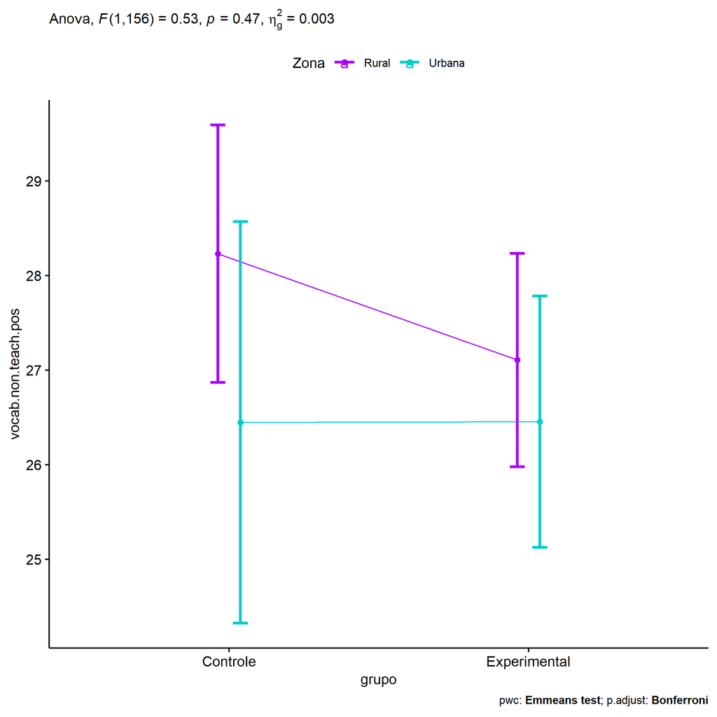

```r
if (!is.null(plots[["grupo"]]))
  plots[["grupo"]] + ggplot2::scale_color_manual(values = color[["Zona"]])
```

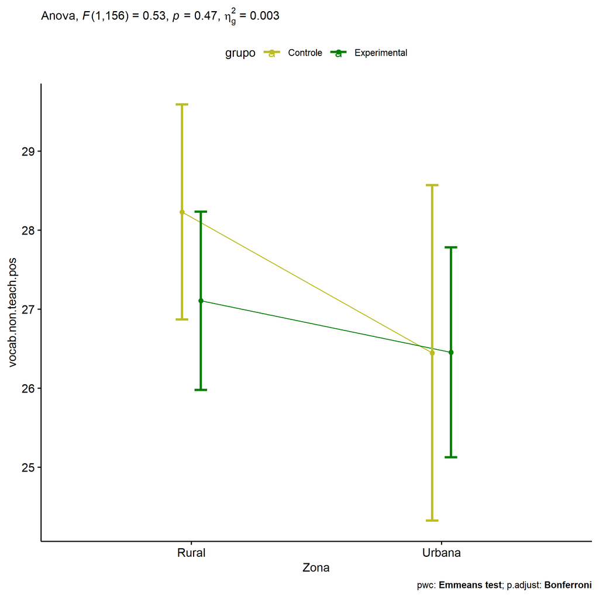

```r
if (!is.null(plots[["Zona"]]))
  plots[["Zona"]] + ggplot2::scale_color_manual(values = color[["grupo"]])
```

```r
plots <- twoWayAncovaBoxPlots(
  wdat, "vocab.non.teach.pos", c("grupo","Zona"), aov, pwcs, covar = "vocab.non.teach.pre",
  theme = "classic", color = color[["grupo:Zona"]],
  subtitle = which(aov$Effect == "grupo:Zona"))
```

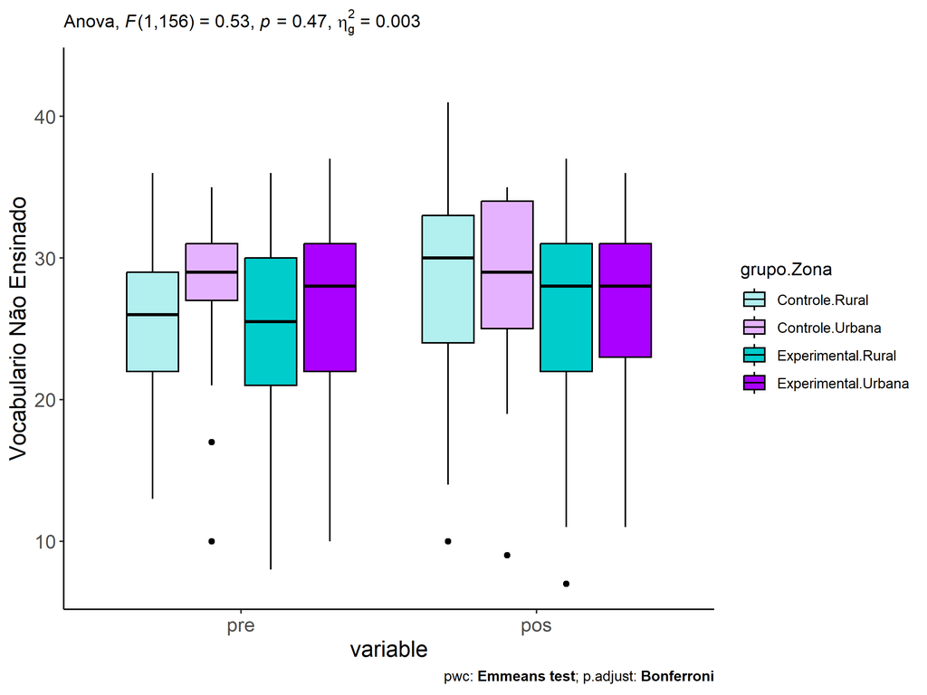

```r
plots[["grupo:Zona"]] + ggplot2::ylab("Vocabulario Não Ensinado") + ggplot2::scale_x_discrete(labels=c('pre', 'pos'))
```

```r
plots <- twoWayAncovaBoxPlots(
  wdat.long, "vocab.non.teach", c("grupo","Zona"), aov, pwc.long, pre.post = "time",
  theme = "classic", color = color$prepost)
```

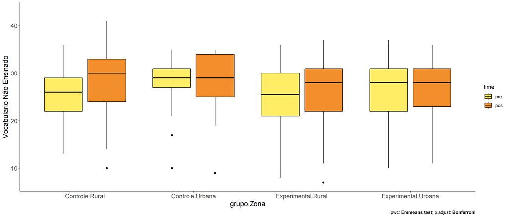

```r
plots[["grupo:Zona"]] + ggplot2::ylab("Vocabulario Não Ensinado")
```

### Checking linearity assumption

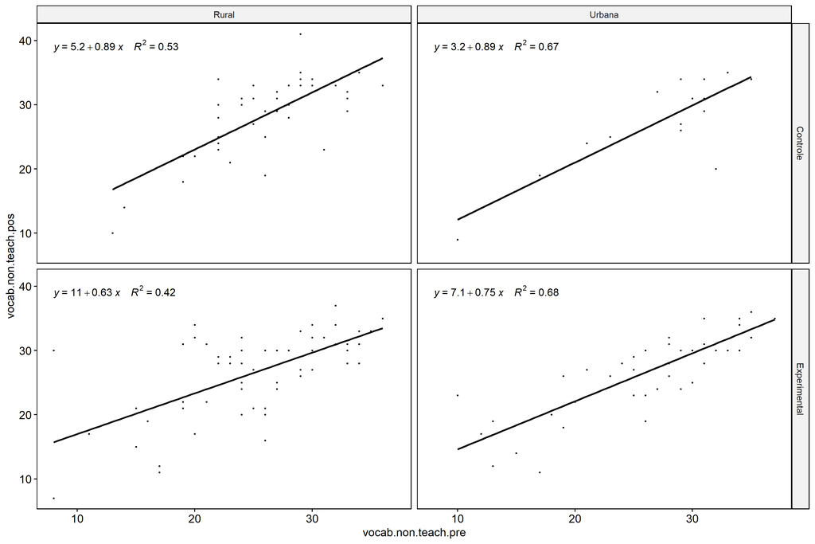

```r
ggscatter(wdat, x = "vocab.non.teach.pre", y = "vocab.non.teach.pos", size = 0.5,
          facet.by = c("grupo","Zona"), add = "reg.line")+
  stat_regline_equation(
    aes(label =  paste(..eq.label.., ..rr.label.., sep = "~~~~"))
  )
```

### Checking normality and homogeneity

```r
res <- augment(lm(vocab.non.teach.pos ~ vocab.non.teach.pre + grupo*Zona, data = wdat))
```

```r
shapiro_test(res$.resid)
```

```
## # A tibble: 1 × 3
##   variable   statistic p.value
##   <chr>          <dbl>   <dbl>
## 1 res$.resid     0.983  0.0520
```

```r
levene_test(res, .resid ~ grupo*Zona)
```

```
## # A tibble: 1 × 4
##     df1   df2 statistic     p
##   <int> <int>     <dbl> <dbl>
## 1     3   157     0.960 0.413
```

# ANCOVA and Pairwise for two factors **grupo:Cor.Raca**

## Without remove non-normal data

```r
pdat = remove_group_data(dat[!is.na(dat[["grupo"]]) & !is.na(dat[["Cor.Raca"]]),], "vocab.non.teach.pos", c("grupo","Cor.Raca"))

pdat.long <- rbind(pdat[,c("id","grupo","Cor.Raca")], pdat[,c("id","grupo","Cor.Raca")])
pdat.long[["time"]] <- c(rep("pre", nrow(pdat)), rep("pos", nrow(pdat)))
pdat.long[["time"]] <- factor(pdat.long[["time"]], c("pre","pos"))
pdat.long[["vocab.non.teach"]] <- c(pdat[["vocab.non.teach.pre"]], pdat[["vocab.non.teach.pos"]])

aov = anova_test(pdat, vocab.non.teach.pos ~ vocab.non.teach.pre + grupo*Cor.Raca)
laov[["grupo:Cor.Raca"]] <- get_anova_table(aov)
```

```r
pwcs <- list()
pwcs[["Cor.Raca"]] <- emmeans_test(
  group_by(pdat, grupo), vocab.non.teach.pos ~ Cor.Raca,
  covariate = vocab.non.teach.pre, p.adjust.method = "bonferroni")
pwcs[["grupo"]] <- emmeans_test(
  group_by(pdat, Cor.Raca), vocab.non.teach.pos ~ grupo,
  covariate = vocab.non.teach.pre, p.adjust.method = "bonferroni")

pwc <- plyr::rbind.fill(pwcs[["grupo"]], pwcs[["Cor.Raca"]])
pwc <- pwc[,c("grupo","Cor.Raca", colnames(pwc)[!colnames(pwc) %in% c("grupo","Cor.Raca")])]
```

```r
pwc.long <- emmeans_test(dplyr::group_by_at(pdat.long, c("grupo","Cor.Raca")),
                         vocab.non.teach ~ time,
                         p.adjust.method = "bonferroni")
lpwc[["grupo:Cor.Raca"]] <- plyr::rbind.fill(pwc, pwc.long)
```

```r
ds <- get.descriptives(pdat, "vocab.non.teach.pos", c("grupo","Cor.Raca"), covar = "vocab.non.teach.pre")
ds <- merge(ds[ds$variable != "vocab.non.teach.pre",],
            ds[ds$variable == "vocab.non.teach.pre", !colnames(ds) %in% c("variable")],
            by = c("grupo","Cor.Raca"), all.x = T, suffixes = c("", ".vocab.non.teach.pre"))
ds <- merge(get_emmeans(pwcs[["grupo"]]), ds, by = c("grupo","Cor.Raca"), suffixes = c(".emms", ""))
ds <- ds[,c("grupo","Cor.Raca","n","mean.vocab.non.teach.pre","se.vocab.non.teach.pre","mean","se","emmean","se.emms")]

colnames(ds) <- c("grupo","Cor.Raca", "N", paste0(c("M","SE")," (pre)"),
                  paste0(c("M","SE"), " (unadj)"), paste0(c("M", "SE"), " (adj)"))

lemms[["grupo:Cor.Raca"]] <- ds
```

## Computing ANCOVA and PairWise After removing non-normal data (OK)

```r
wdat = pdat

res = residuals(lm(vocab.non.teach.pos ~ vocab.non.teach.pre + grupo*Cor.Raca, data = wdat))
non.normal = getNonNormal(res, wdat$id, plimit = 0.05)

wdat = wdat[!wdat$id %in% non.normal,]

wdat.long <- rbind(wdat[,c("id","grupo","Cor.Raca")], wdat[,c("id","grupo","Cor.Raca")])
wdat.long[["time"]] <- c(rep("pre", nrow(wdat)), rep("pos", nrow(wdat)))
wdat.long[["time"]] <- factor(wdat.long[["time"]], c("pre","pos"))
wdat.long[["vocab.non.teach"]] <- c(wdat[["vocab.non.teach.pre"]], wdat[["vocab.non.teach.pos"]])


ldat[["grupo:Cor.Raca"]] = wdat

(non.normal)
```

```
## [1] "P1139" "P1113" "P1112" "P3260" "P1151"
```

```r
aov = anova_test(wdat, vocab.non.teach.pos ~ vocab.non.teach.pre + grupo*Cor.Raca)
laov[["grupo:Cor.Raca"]] <- merge(get_anova_table(aov), laov[["grupo:Cor.Raca"]], by="Effect", suffixes = c("","'"))

(df = get_anova_table(aov))
```

```
## ANOVA Table (type II tests)
##
##                Effect DFn DFd       F        p p<.05   ges
## 1 vocab.non.teach.pre   1 106 130.595 3.41e-20     * 0.552
## 2               grupo   1 106   0.662 4.18e-01       0.006
## 3            Cor.Raca   1 106   1.965 1.64e-01       0.018
## 4      grupo:Cor.Raca   1 106   1.243 2.67e-01       0.012
```

| Effect | DFn | DFd | F | p | p<.05 | ges |
| --- | --- | --- | --- | --- | --- | --- |
| vocab.non.teach.pre | 1 | 106 | 130.595 | 0.000 | * | 0.552 |
| grupo | 1 | 106 | 0.662 | 0.418 |  | 0.006 |
| Cor.Raca | 1 | 106 | 1.965 | 0.164 |  | 0.018 |
| grupo:Cor.Raca | 1 | 106 | 1.243 | 0.267 |  | 0.012 |

```r
pwcs <- list()
pwcs[["Cor.Raca"]] <- emmeans_test(
  group_by(wdat, grupo), vocab.non.teach.pos ~ Cor.Raca,
  covariate = vocab.non.teach.pre, p.adjust.method = "bonferroni")
pwcs[["grupo"]] <- emmeans_test(
  group_by(wdat, Cor.Raca), vocab.non.teach.pos ~ grupo,
  covariate = vocab.non.teach.pre, p.adjust.method = "bonferroni")

pwc <- plyr::rbind.fill(pwcs[["grupo"]], pwcs[["Cor.Raca"]])
pwc <- pwc[,c("grupo","Cor.Raca", colnames(pwc)[!colnames(pwc) %in% c("grupo","Cor.Raca")])]
```

| grupo | Cor.Raca | term | .y. | group1 | group2 | df | statistic | p | p.adj | p.adj.signif |
| --- | --- | --- | --- | --- | --- | --- | --- | --- | --- | --- |
|  | Branca | vocab.non.teach.pre*grupo | vocab.non.teach.pos | Controle | Experimental | 106 | 1.350 | 0.180 | 0.180 | ns |
|  | Parda | vocab.non.teach.pre*grupo | vocab.non.teach.pos | Controle | Experimental | 106 | 0.282 | 0.778 | 0.778 | ns |
| Controle |  | vocab.non.teach.pre*Cor.Raca | vocab.non.teach.pos | Branca | Parda | 106 | 1.744 | 0.084 | 0.084 | ns |
| Experimental |  | vocab.non.teach.pre*Cor.Raca | vocab.non.teach.pos | Branca | Parda | 106 | 0.436 | 0.664 | 0.664 | ns |

```r
pwc.long <- emmeans_test(dplyr::group_by_at(wdat.long, c("grupo","Cor.Raca")),
                         vocab.non.teach ~ time,
                         p.adjust.method = "bonferroni")
lpwc[["grupo:Cor.Raca"]] <- merge(plyr::rbind.fill(pwc, pwc.long), lpwc[["grupo:Cor.Raca"]], by=c("grupo","Cor.Raca","term",".y.","group1","group2"), suffixes = c("","'"))
```

| grupo | Cor.Raca | term | .y. | group1 | group2 | df | statistic | p | p.adj | p.adj.signif |
| --- | --- | --- | --- | --- | --- | --- | --- | --- | --- | --- |
| Controle | Branca | time | vocab.non.teach | pre | pos | 214 | -1.105 | 0.270 | 0.270 | ns |
| Controle | Parda | time | vocab.non.teach | pre | pos | 214 | -0.743 | 0.458 | 0.458 | ns |
| Experimental | Branca | time | vocab.non.teach | pre | pos | 214 | -0.300 | 0.764 | 0.764 | ns |
| Experimental | Parda | time | vocab.non.teach | pre | pos | 214 | -0.750 | 0.454 | 0.454 | ns |

```r
ds <- get.descriptives(wdat, "vocab.non.teach.pos", c("grupo","Cor.Raca"), covar = "vocab.non.teach.pre")
ds <- merge(ds[ds$variable != "vocab.non.teach.pre",],
            ds[ds$variable == "vocab.non.teach.pre", !colnames(ds) %in% c("variable")],
            by = c("grupo","Cor.Raca"), all.x = T, suffixes = c("", ".vocab.non.teach.pre"))
ds <- merge(get_emmeans(pwcs[["grupo"]]), ds, by = c("grupo","Cor.Raca"), suffixes = c(".emms", ""))
ds <- ds[,c("grupo","Cor.Raca","n","mean.vocab.non.teach.pre","se.vocab.non.teach.pre","mean","se","emmean","se.emms")]

colnames(ds) <- c("grupo","Cor.Raca", "N", paste0(c("M","SE")," (pre)"),
                  paste0(c("M","SE"), " (unadj)"), paste0(c("M", "SE"), " (adj)"))

lemms[["grupo:Cor.Raca"]] <- merge(ds, lemms[["grupo:Cor.Raca"]], by=c("grupo","Cor.Raca"), suffixes = c("","'"))
```

| grupo | Cor.Raca | N | M (pre) | SE (pre) | M (unadj) | SE (unadj) | M (adj) | SE (adj) |
| --- | --- | --- | --- | --- | --- | --- | --- | --- |
| Controle | Branca | 7 | 27.429 | 1.152 | 31.286 | 0.644 | 29.591 | 1.725 |
| Controle | Parda | 43 | 25.279 | 0.951 | 26.326 | 0.992 | 26.347 | 0.693 |
| Experimental | Branca | 13 | 28.462 | 1.496 | 29.231 | 1.787 | 26.711 | 1.280 |
| Experimental | Parda | 48 | 24.167 | 0.986 | 25.167 | 1.074 | 26.077 | 0.661 |

### Plots for ancova

```r
plots <- twoWayAncovaPlots(
  wdat, "vocab.non.teach.pos", c("grupo","Cor.Raca"), aov, pwcs, addParam = c("mean_se"),
  font.label.size=10, step.increase=0.05, p.label="p.adj",
  subtitle = which(aov$Effect == "grupo:Cor.Raca"))
```

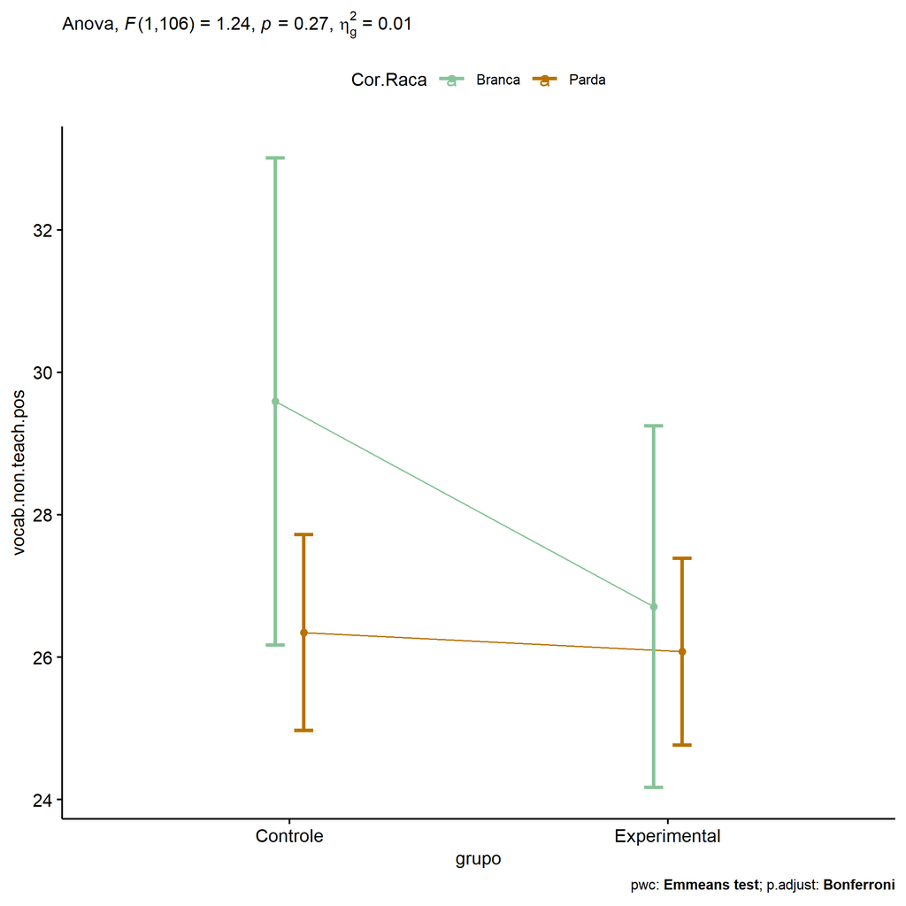

```r
if (!is.null(plots[["grupo"]]))
  plots[["grupo"]] + ggplot2::scale_color_manual(values = color[["Cor.Raca"]])
```

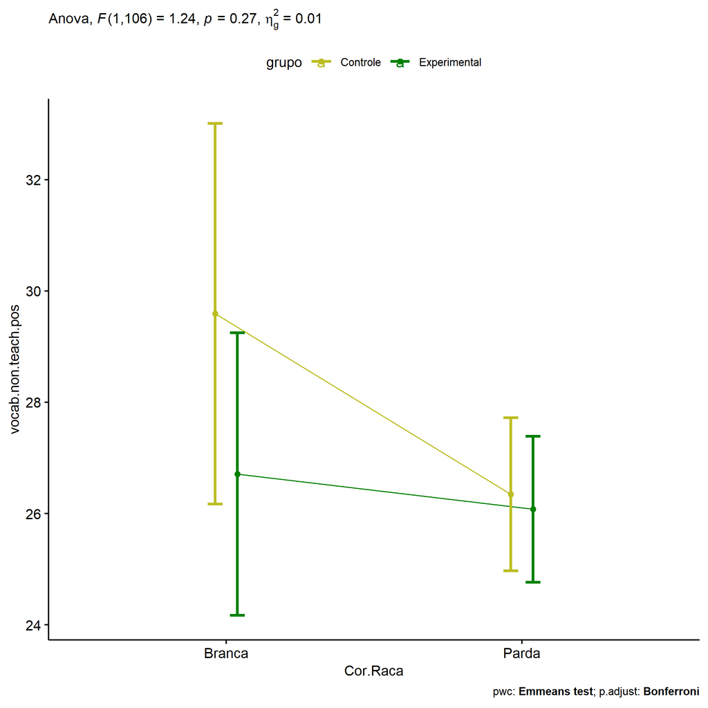

```r
if (!is.null(plots[["Cor.Raca"]]))
  plots[["Cor.Raca"]] + ggplot2::scale_color_manual(values = color[["grupo"]])
```

```r
plots <- twoWayAncovaBoxPlots(
  wdat, "vocab.non.teach.pos", c("grupo","Cor.Raca"), aov, pwcs, covar = "vocab.non.teach.pre",
  theme = "classic", color = color[["grupo:Cor.Raca"]],
  subtitle = which(aov$Effect == "grupo:Cor.Raca"))
```

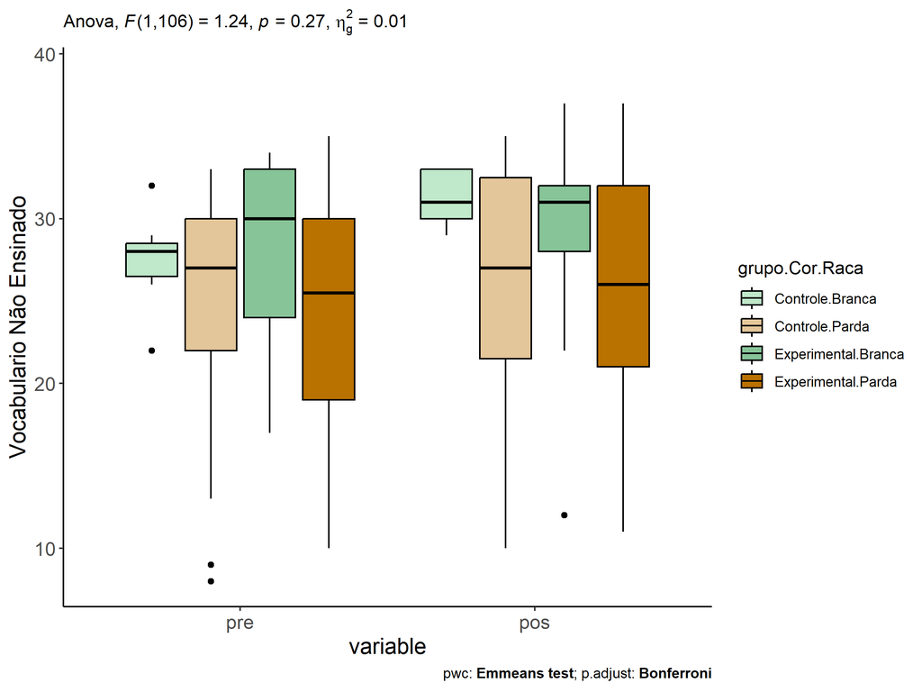

```r
plots[["grupo:Cor.Raca"]] + ggplot2::ylab("Vocabulario Não Ensinado") + ggplot2::scale_x_discrete(labels=c('pre', 'pos'))
```

```r
plots <- twoWayAncovaBoxPlots(
  wdat.long, "vocab.non.teach", c("grupo","Cor.Raca"), aov, pwc.long, pre.post = "time",
  theme = "classic", color = color$prepost)
```

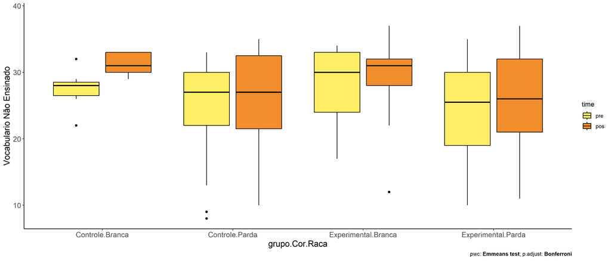

```r
plots[["grupo:Cor.Raca"]] + ggplot2::ylab("Vocabulario Não Ensinado")
```

### Checking linearity assumption

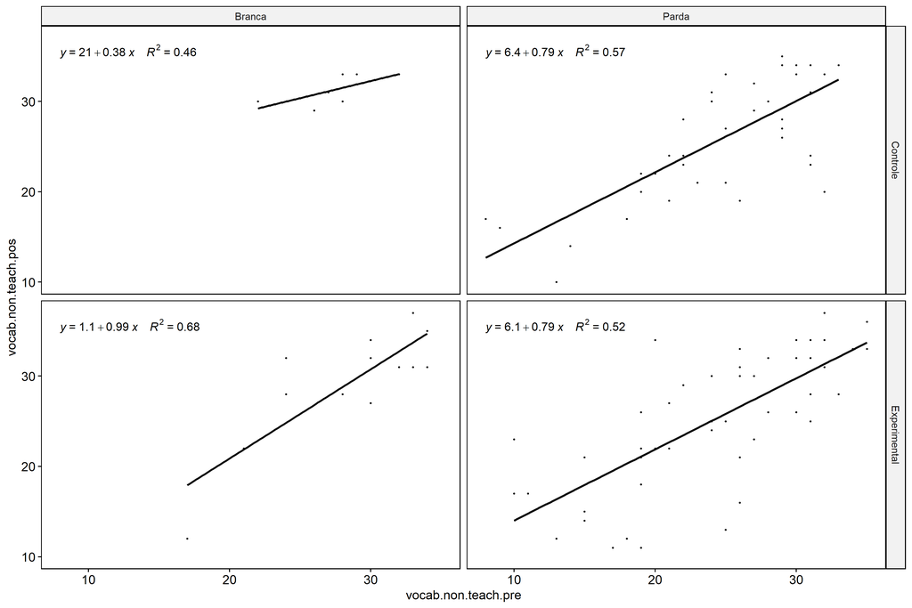

```r
ggscatter(wdat, x = "vocab.non.teach.pre", y = "vocab.non.teach.pos", size = 0.5,
          facet.by = c("grupo","Cor.Raca"), add = "reg.line")+
  stat_regline_equation(
    aes(label =  paste(..eq.label.., ..rr.label.., sep = "~~~~"))
  )
```

### Checking normality and homogeneity

```r
res <- augment(lm(vocab.non.teach.pos ~ vocab.non.teach.pre + grupo*Cor.Raca, data = wdat))
```

```r
shapiro_test(res$.resid)
```

```
## # A tibble: 1 × 3
##   variable   statistic p.value
##   <chr>          <dbl>   <dbl>
## 1 res$.resid     0.977  0.0487
```

```r
levene_test(res, .resid ~ grupo*Cor.Raca)
```

```
## # A tibble: 1 × 4
##     df1   df2 statistic     p
##   <int> <int>     <dbl> <dbl>
## 1     3   107      2.12 0.102
```

# ANCOVA and Pairwise for two factors **grupo:vocab.non.teach.quintile**

## Without remove non-normal data

```r
pdat = remove_group_data(dat[!is.na(dat[["grupo"]]) & !is.na(dat[["vocab.non.teach.quintile"]]),], "vocab.non.teach.pos", c("grupo","vocab.non.teach.quintile"))

pdat.long <- rbind(pdat[,c("id","grupo","vocab.non.teach.quintile")], pdat[,c("id","grupo","vocab.non.teach.quintile")])
pdat.long[["time"]] <- c(rep("pre", nrow(pdat)), rep("pos", nrow(pdat)))
pdat.long[["time"]] <- factor(pdat.long[["time"]], c("pre","pos"))
pdat.long[["vocab.non.teach"]] <- c(pdat[["vocab.non.teach.pre"]], pdat[["vocab.non.teach.pos"]])

aov = anova_test(pdat, vocab.non.teach.pos ~ vocab.non.teach.pre + grupo*vocab.non.teach.quintile)
laov[["grupo:vocab.non.teach.quintile"]] <- get_anova_table(aov)
```

```r
pwcs <- list()
pwcs[["vocab.non.teach.quintile"]] <- emmeans_test(
  group_by(pdat, grupo), vocab.non.teach.pos ~ vocab.non.teach.quintile,
  covariate = vocab.non.teach.pre, p.adjust.method = "bonferroni")
pwcs[["grupo"]] <- emmeans_test(
  group_by(pdat, vocab.non.teach.quintile), vocab.non.teach.pos ~ grupo,
  covariate = vocab.non.teach.pre, p.adjust.method = "bonferroni")

pwc <- plyr::rbind.fill(pwcs[["grupo"]], pwcs[["vocab.non.teach.quintile"]])
pwc <- pwc[,c("grupo","vocab.non.teach.quintile", colnames(pwc)[!colnames(pwc) %in% c("grupo","vocab.non.teach.quintile")])]
```

```r
pwc.long <- emmeans_test(dplyr::group_by_at(pdat.long, c("grupo","vocab.non.teach.quintile")),
                         vocab.non.teach ~ time,
                         p.adjust.method = "bonferroni")
lpwc[["grupo:vocab.non.teach.quintile"]] <- plyr::rbind.fill(pwc, pwc.long)
```

```r
ds <- get.descriptives(pdat, "vocab.non.teach.pos", c("grupo","vocab.non.teach.quintile"), covar = "vocab.non.teach.pre")
ds <- merge(ds[ds$variable != "vocab.non.teach.pre",],
            ds[ds$variable == "vocab.non.teach.pre", !colnames(ds) %in% c("variable")],
            by = c("grupo","vocab.non.teach.quintile"), all.x = T, suffixes = c("", ".vocab.non.teach.pre"))
ds <- merge(get_emmeans(pwcs[["grupo"]]), ds, by = c("grupo","vocab.non.teach.quintile"), suffixes = c(".emms", ""))
ds <- ds[,c("grupo","vocab.non.teach.quintile","n","mean.vocab.non.teach.pre","se.vocab.non.teach.pre","mean","se","emmean","se.emms")]

colnames(ds) <- c("grupo","vocab.non.teach.quintile", "N", paste0(c("M","SE")," (pre)"),
                  paste0(c("M","SE"), " (unadj)"), paste0(c("M", "SE"), " (adj)"))

lemms[["grupo:vocab.non.teach.quintile"]] <- ds
```

## Computing ANCOVA and PairWise After removing non-normal data (OK)

```r
wdat = pdat

res = residuals(lm(vocab.non.teach.pos ~ vocab.non.teach.pre + grupo*vocab.non.teach.quintile, data = wdat))
non.normal = getNonNormal(res, wdat$id, plimit = 0.05)

wdat = wdat[!wdat$id %in% non.normal,]

wdat.long <- rbind(wdat[,c("id","grupo","vocab.non.teach.quintile")], wdat[,c("id","grupo","vocab.non.teach.quintile")])
wdat.long[["time"]] <- c(rep("pre", nrow(wdat)), rep("pos", nrow(wdat)))
wdat.long[["time"]] <- factor(wdat.long[["time"]], c("pre","pos"))
wdat.long[["vocab.non.teach"]] <- c(wdat[["vocab.non.teach.pre"]], wdat[["vocab.non.teach.pos"]])


ldat[["grupo:vocab.non.teach.quintile"]] = wdat

(non.normal)
```

```
## [1] "P1113" "P1139" "P2304" "P1112"
```

```r
aov = anova_test(wdat, vocab.non.teach.pos ~ vocab.non.teach.pre + grupo*vocab.non.teach.quintile)
laov[["grupo:vocab.non.teach.quintile"]] <- merge(get_anova_table(aov), laov[["grupo:vocab.non.teach.quintile"]], by="Effect", suffixes = c("","'"))

(df = get_anova_table(aov))
```

```
## ANOVA Table (type II tests)
##
##                           Effect DFn DFd      F        p p<.05   ges
## 1            vocab.non.teach.pre   1 274 19.146 1.72e-05     * 0.065
## 2                          grupo   1 274  0.708 4.01e-01       0.003
## 3       vocab.non.teach.quintile   4 274  2.300 5.90e-02       0.032
## 4 grupo:vocab.non.teach.quintile   4 274  2.690 3.20e-02     * 0.038
```

| Effect | DFn | DFd | F | p | p<.05 | ges |
| --- | --- | --- | --- | --- | --- | --- |
| vocab.non.teach.pre | 1 | 274 | 19.146 | 0.000 | * | 0.065 |
| grupo | 1 | 274 | 0.708 | 0.401 |  | 0.003 |
| vocab.non.teach.quintile | 4 | 274 | 2.300 | 0.059 |  | 0.032 |
| grupo:vocab.non.teach.quintile | 4 | 274 | 2.690 | 0.032 | * | 0.038 |

```r
pwcs <- list()
pwcs[["vocab.non.teach.quintile"]] <- emmeans_test(
  group_by(wdat, grupo), vocab.non.teach.pos ~ vocab.non.teach.quintile,
  covariate = vocab.non.teach.pre, p.adjust.method = "bonferroni")
pwcs[["grupo"]] <- emmeans_test(
  group_by(wdat, vocab.non.teach.quintile), vocab.non.teach.pos ~ grupo,
  covariate = vocab.non.teach.pre, p.adjust.method = "bonferroni")

pwc <- plyr::rbind.fill(pwcs[["grupo"]], pwcs[["vocab.non.teach.quintile"]])
pwc <- pwc[,c("grupo","vocab.non.teach.quintile", colnames(pwc)[!colnames(pwc) %in% c("grupo","vocab.non.teach.quintile")])]
```

| grupo | vocab.non.teach.quintile | term | .y. | group1 | group2 | df | statistic | p | p.adj | p.adj.signif |
| --- | --- | --- | --- | --- | --- | --- | --- | --- | --- | --- |
|  | 1st quintile | vocab.non.teach.pre*grupo | vocab.non.teach.pos | Controle | Experimental | 274 | -0.781 | 0.436 | 0.436 | ns |
|  | 2nd quintile | vocab.non.teach.pre*grupo | vocab.non.teach.pos | Controle | Experimental | 274 | 0.733 | 0.464 | 0.464 | ns |
|  | 3rd quintile | vocab.non.teach.pre*grupo | vocab.non.teach.pos | Controle | Experimental | 274 | -0.903 | 0.367 | 0.367 | ns |
|  | 4th quintile | vocab.non.teach.pre*grupo | vocab.non.teach.pos | Controle | Experimental | 274 | 2.971 | 0.003 | 0.003 | ** |
|  | 5th quintile | vocab.non.teach.pre*grupo | vocab.non.teach.pos | Controle | Experimental | 274 | -0.813 | 0.417 | 0.417 | ns |
| Controle |  | vocab.non.teach.pre*vocab.non.teach.quintile | vocab.non.teach.pos | 1st quintile | 2nd quintile | 274 | 0.467 | 0.641 | 1.000 | ns |
| Controle |  | vocab.non.teach.pre*vocab.non.teach.quintile | vocab.non.teach.pos | 1st quintile | 3rd quintile | 274 | -0.101 | 0.919 | 1.000 | ns |
| Controle |  | vocab.non.teach.pre*vocab.non.teach.quintile | vocab.non.teach.pos | 1st quintile | 4th quintile | 274 | -0.445 | 0.657 | 1.000 | ns |
| Controle |  | vocab.non.teach.pre*vocab.non.teach.quintile | vocab.non.teach.pos | 1st quintile | 5th quintile | 274 | 0.134 | 0.893 | 1.000 | ns |
| Controle |  | vocab.non.teach.pre*vocab.non.teach.quintile | vocab.non.teach.pos | 2nd quintile | 3rd quintile | 274 | -0.818 | 0.414 | 1.000 | ns |
| Controle |  | vocab.non.teach.pre*vocab.non.teach.quintile | vocab.non.teach.pos | 2nd quintile | 4th quintile | 274 | -1.188 | 0.236 | 1.000 | ns |
| Controle |  | vocab.non.teach.pre*vocab.non.teach.quintile | vocab.non.teach.pos | 2nd quintile | 5th quintile | 274 | -0.233 | 0.816 | 1.000 | ns |
| Controle |  | vocab.non.teach.pre*vocab.non.teach.quintile | vocab.non.teach.pos | 3rd quintile | 4th quintile | 274 | -0.873 | 0.383 | 1.000 | ns |
| Controle |  | vocab.non.teach.pre*vocab.non.teach.quintile | vocab.non.teach.pos | 3rd quintile | 5th quintile | 274 | 0.429 | 0.668 | 1.000 | ns |
| Controle |  | vocab.non.teach.pre*vocab.non.teach.quintile | vocab.non.teach.pos | 4th quintile | 5th quintile | 274 | 1.673 | 0.095 | 0.955 | ns |
| Experimental |  | vocab.non.teach.pre*vocab.non.teach.quintile | vocab.non.teach.pos | 1st quintile | 2nd quintile | 274 | 2.042 | 0.042 | 0.421 | ns |
| Experimental |  | vocab.non.teach.pre*vocab.non.teach.quintile | vocab.non.teach.pos | 1st quintile | 3rd quintile | 274 | 0.246 | 0.806 | 1.000 | ns |
| Experimental |  | vocab.non.teach.pre*vocab.non.teach.quintile | vocab.non.teach.pos | 1st quintile | 4th quintile | 274 | 1.037 | 0.300 | 1.000 | ns |
| Experimental |  | vocab.non.teach.pre*vocab.non.teach.quintile | vocab.non.teach.pos | 1st quintile | 5th quintile | 274 | 0.457 | 0.648 | 1.000 | ns |
| Experimental |  | vocab.non.teach.pre*vocab.non.teach.quintile | vocab.non.teach.pos | 2nd quintile | 3rd quintile | 274 | -2.511 | 0.013 | 0.126 | ns |
| Experimental |  | vocab.non.teach.pre*vocab.non.teach.quintile | vocab.non.teach.pos | 2nd quintile | 4th quintile | 274 | -0.640 | 0.523 | 1.000 | ns |
| Experimental |  | vocab.non.teach.pre*vocab.non.teach.quintile | vocab.non.teach.pos | 2nd quintile | 5th quintile | 274 | -1.012 | 0.312 | 1.000 | ns |
| Experimental |  | vocab.non.teach.pre*vocab.non.teach.quintile | vocab.non.teach.pos | 3rd quintile | 4th quintile | 274 | 2.144 | 0.033 | 0.329 | ns |
| Experimental |  | vocab.non.teach.pre*vocab.non.teach.quintile | vocab.non.teach.pos | 3rd quintile | 5th quintile | 274 | 0.607 | 0.544 | 1.000 | ns |
| Experimental |  | vocab.non.teach.pre*vocab.non.teach.quintile | vocab.non.teach.pos | 4th quintile | 5th quintile | 274 | -1.219 | 0.224 | 1.000 | ns |

```r
pwc.long <- emmeans_test(dplyr::group_by_at(wdat.long, c("grupo","vocab.non.teach.quintile")),
                         vocab.non.teach ~ time,
                         p.adjust.method = "bonferroni")
lpwc[["grupo:vocab.non.teach.quintile"]] <- merge(plyr::rbind.fill(pwc, pwc.long), lpwc[["grupo:vocab.non.teach.quintile"]], by=c("grupo","vocab.non.teach.quintile","term",".y.","group1","group2"), suffixes = c("","'"))
```

| grupo | vocab.non.teach.quintile | term | .y. | group1 | group2 | df | statistic | p | p.adj | p.adj.signif |
| --- | --- | --- | --- | --- | --- | --- | --- | --- | --- | --- |
| Controle | 1st quintile | time | vocab.non.teach | pre | pos | 550 | -2.373 | 0.018 | 0.018 | * |
| Controle | 2nd quintile | time | vocab.non.teach | pre | pos | 550 | -1.356 | 0.176 | 0.176 | ns |
| Controle | 3rd quintile | time | vocab.non.teach | pre | pos | 550 | -2.164 | 0.031 | 0.031 | * |
| Controle | 4th quintile | time | vocab.non.teach | pre | pos | 550 | -2.279 | 0.023 | 0.023 | * |
| Controle | 5th quintile | time | vocab.non.teach | pre | pos | 550 | 2.072 | 0.039 | 0.039 | * |
| Experimental | 1st quintile | time | vocab.non.teach | pre | pos | 550 | -4.114 | 0.000 | 0.000 | **** |
| Experimental | 2nd quintile | time | vocab.non.teach | pre | pos | 550 | -0.510 | 0.610 | 0.610 | ns |
| Experimental | 3rd quintile | time | vocab.non.teach | pre | pos | 550 | -3.830 | 0.000 | 0.000 | *** |
| Experimental | 4th quintile | time | vocab.non.teach | pre | pos | 550 | 1.227 | 0.220 | 0.220 | ns |
| Experimental | 5th quintile | time | vocab.non.teach | pre | pos | 550 | 1.234 | 0.218 | 0.218 | ns |

```r
ds <- get.descriptives(wdat, "vocab.non.teach.pos", c("grupo","vocab.non.teach.quintile"), covar = "vocab.non.teach.pre")
ds <- merge(ds[ds$variable != "vocab.non.teach.pre",],
            ds[ds$variable == "vocab.non.teach.pre", !colnames(ds) %in% c("variable")],
            by = c("grupo","vocab.non.teach.quintile"), all.x = T, suffixes = c("", ".vocab.non.teach.pre"))
ds <- merge(get_emmeans(pwcs[["grupo"]]), ds, by = c("grupo","vocab.non.teach.quintile"), suffixes = c(".emms", ""))
ds <- ds[,c("grupo","vocab.non.teach.quintile","n","mean.vocab.non.teach.pre","se.vocab.non.teach.pre","mean","se","emmean","se.emms")]

colnames(ds) <- c("grupo","vocab.non.teach.quintile", "N", paste0(c("M","SE")," (pre)"),
                  paste0(c("M","SE"), " (unadj)"), paste0(c("M", "SE"), " (adj)"))

lemms[["grupo:vocab.non.teach.quintile"]] <- merge(ds, lemms[["grupo:vocab.non.teach.quintile"]], by=c("grupo","vocab.non.teach.quintile"), suffixes = c("","'"))
```

| grupo | vocab.non.teach.quintile | N | M (pre) | SE (pre) | M (unadj) | SE (unadj) | M (adj) | SE (adj) |
| --- | --- | --- | --- | --- | --- | --- | --- | --- |
| Controle | 1st quintile | 5 | 10.400 | 0.927 | 15.600 | 3.043 | 26.862 | 3.258 |
| Controle | 2nd quintile | 10 | 16.900 | 0.640 | 19.000 | 1.585 | 25.615 | 2.069 |
| Controle | 3rd quintile | 25 | 22.240 | 0.254 | 24.360 | 1.020 | 27.158 | 1.099 |
| Controle | 4th quintile | 36 | 27.611 | 0.237 | 29.472 | 0.703 | 28.431 | 0.782 |
| Controle | 5th quintile | 41 | 32.244 | 0.288 | 30.659 | 0.599 | 26.305 | 1.215 |
| Experimental | 1st quintile | 8 | 10.625 | 0.706 | 17.750 | 2.426 | 28.851 | 2.989 |
| Experimental | 2nd quintile | 16 | 17.438 | 0.387 | 18.062 | 1.534 | 24.294 | 1.810 |
| Experimental | 3rd quintile | 35 | 22.257 | 0.251 | 25.429 | 0.831 | 28.215 | 0.988 |
| Experimental | 4th quintile | 56 | 26.946 | 0.191 | 26.143 | 0.666 | 25.577 | 0.611 |
| Experimental | 5th quintile | 53 | 32.245 | 0.268 | 31.415 | 0.435 | 27.061 | 1.169 |

### Plots for ancova

```r
plots <- twoWayAncovaPlots(
  wdat, "vocab.non.teach.pos", c("grupo","vocab.non.teach.quintile"), aov, pwcs, addParam = c("mean_se"),
  font.label.size=10, step.increase=0.05, p.label="p.adj",
  subtitle = which(aov$Effect == "grupo:vocab.non.teach.quintile"))
```

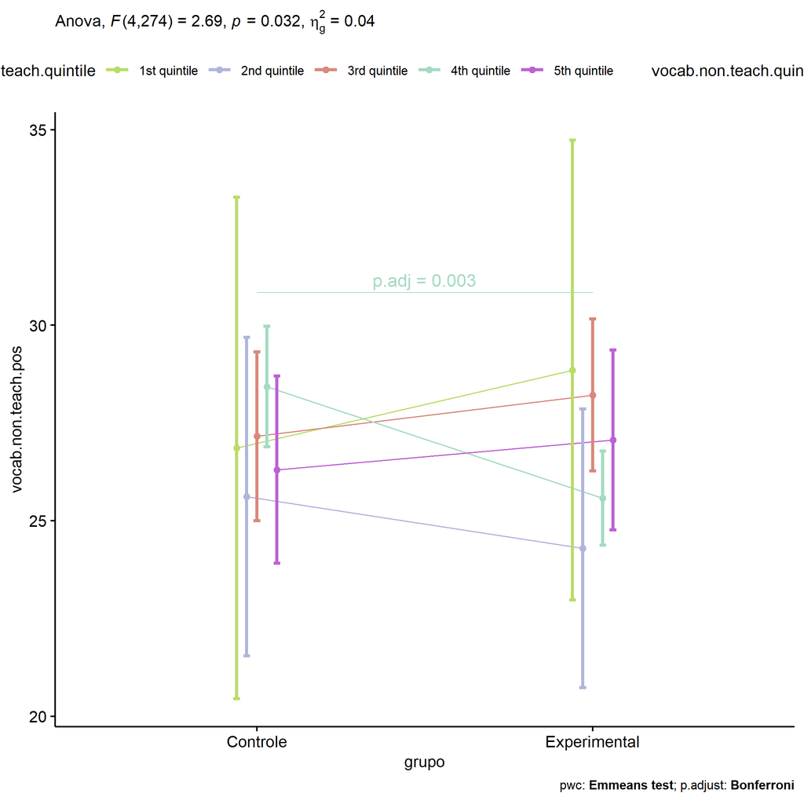

```r
if (!is.null(plots[["grupo"]]))
  plots[["grupo"]] + ggplot2::scale_color_manual(values = color[["vocab.non.teach.quintile"]])
```

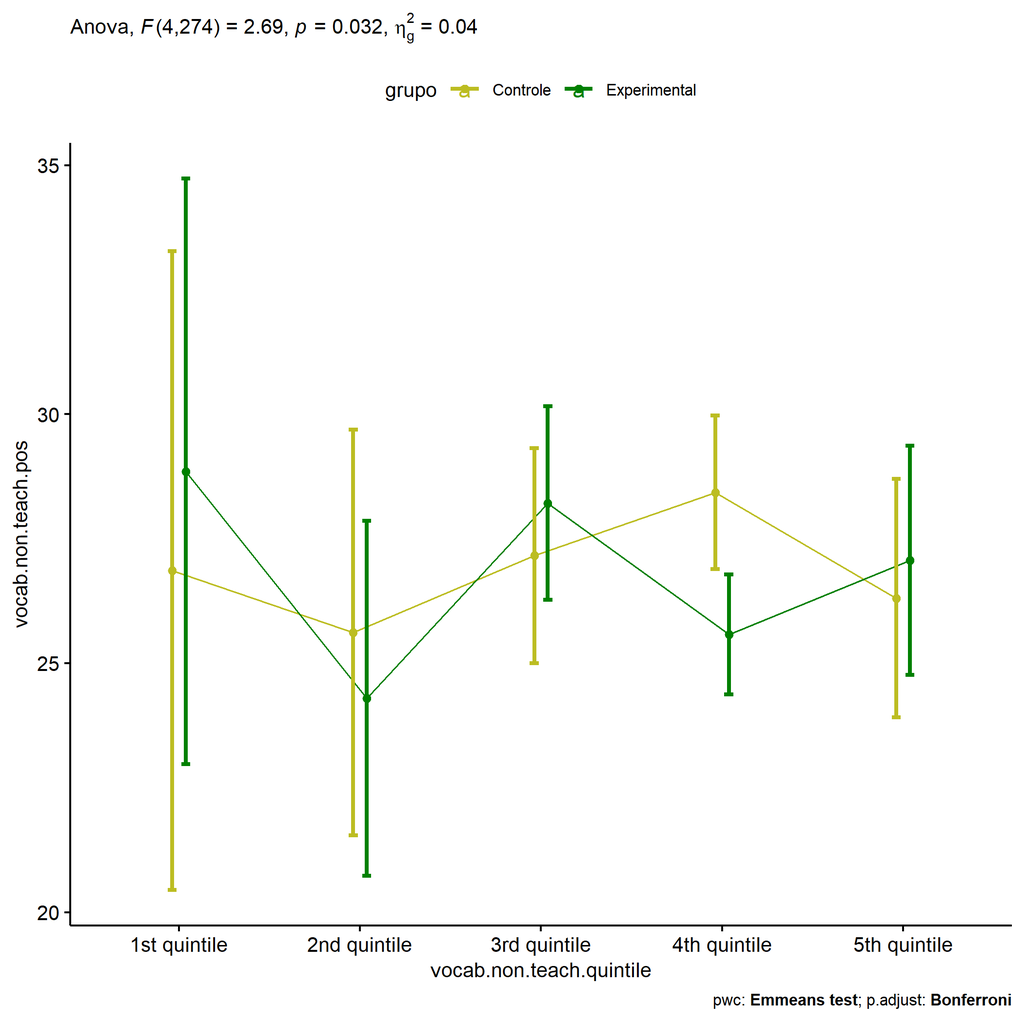

```r
if (!is.null(plots[["vocab.non.teach.quintile"]]))
  plots[["vocab.non.teach.quintile"]] + ggplot2::scale_color_manual(values = color[["grupo"]])
```

```r
plots <- twoWayAncovaBoxPlots(
  wdat, "vocab.non.teach.pos", c("grupo","vocab.non.teach.quintile"), aov, pwcs, covar = "vocab.non.teach.pre",
  theme = "classic", color = color[["grupo:vocab.non.teach.quintile"]],
  subtitle = which(aov$Effect == "grupo:vocab.non.teach.quintile"))
```

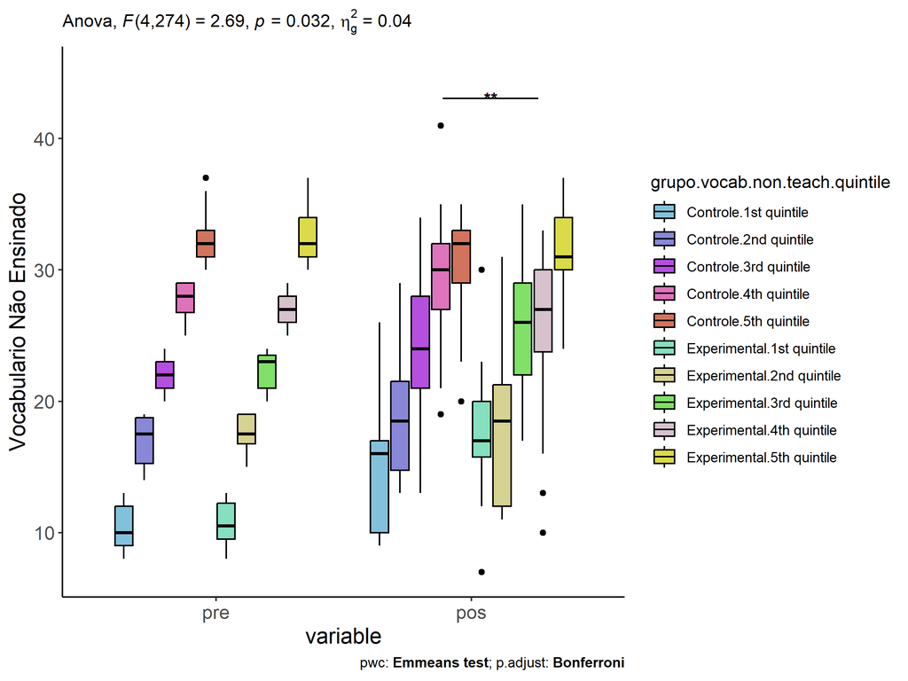

```r
plots[["grupo:vocab.non.teach.quintile"]] + ggplot2::ylab("Vocabulario Não Ensinado") + ggplot2::scale_x_discrete(labels=c('pre', 'pos'))
```

```r
plots <- twoWayAncovaBoxPlots(
  wdat.long, "vocab.non.teach", c("grupo","vocab.non.teach.quintile"), aov, pwc.long, pre.post = "time",
  theme = "classic", color = color$prepost)
```

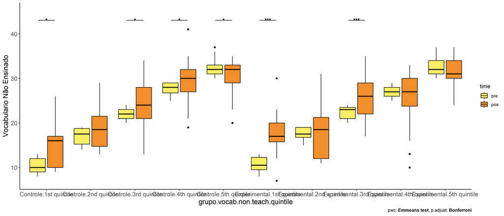

```r
plots[["grupo:vocab.non.teach.quintile"]] + ggplot2::ylab("Vocabulario Não Ensinado")
```

### Checking linearity assumption

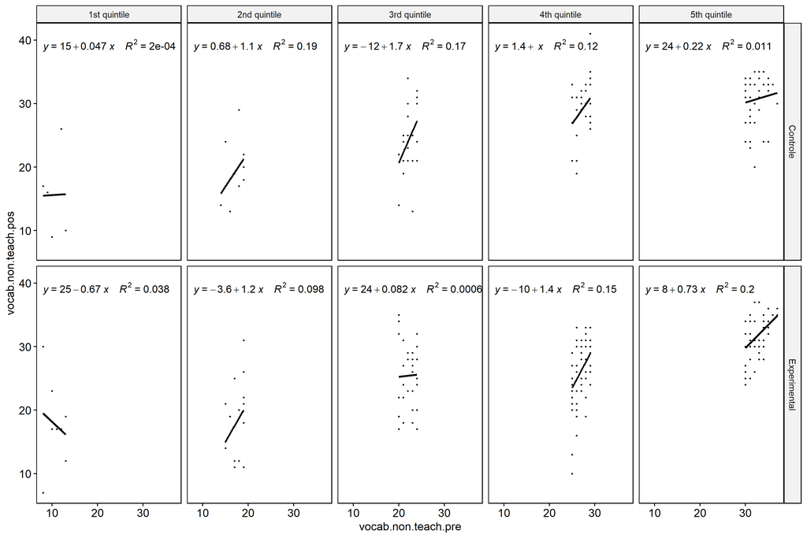

```r
ggscatter(wdat, x = "vocab.non.teach.pre", y = "vocab.non.teach.pos", size = 0.5,
          facet.by = c("grupo","vocab.non.teach.quintile"), add = "reg.line")+
  stat_regline_equation(
    aes(label =  paste(..eq.label.., ..rr.label.., sep = "~~~~"))
  )
```

### Checking normality and homogeneity

```r
res <- augment(lm(vocab.non.teach.pos ~ vocab.non.teach.pre + grupo*vocab.non.teach.quintile, data = wdat))
```

```r
shapiro_test(res$.resid)
```

```
## # A tibble: 1 × 3
##   variable   statistic p.value
##   <chr>          <dbl>   <dbl>
## 1 res$.resid     0.992   0.127
```

```r
levene_test(res, .resid ~ grupo*vocab.non.teach.quintile)
```

```
## # A tibble: 1 × 4
##     df1   df2 statistic      p
##   <int> <int>     <dbl>  <dbl>
## 1     9   275      2.38 0.0133
```

# Summary of Results

## Descriptive Statistics

```r
df <- get.descriptives(ldat[["grupo"]], c(dv.pre, dv.pos), c("grupo"),
                       include.global = T, symmetry.test = T, normality.test = F)
df <- plyr::rbind.fill(
  df, do.call(plyr::rbind.fill, lapply(lfatores2, FUN = function(f) {
    if (nrow(dat) > 0 && sum(!is.na(unique(dat[[f]]))) > 1)
      get.descriptives(ldat[[paste0("grupo:",f)]], c(dv.pre,dv.pos), c("grupo", f),
                       symmetry.test = T, normality.test = F)
    }))
)
(df <- df[,c(fatores1[fatores1 %in% colnames(df)],"variable",
             colnames(df)[!colnames(df) %in% c(fatores1,"variable")])])
```

```
##           grupo Sexo   Zona Cor.Raca vocab.non.teach.quintile            variable   n   mean median min max
## 1      Controle <NA>   <NA>     <NA>                     <NA> vocab.non.teach.pre 117 26.436   28.0   8  37
## 2  Experimental <NA>   <NA>     <NA>                     <NA> vocab.non.teach.pre 165 26.079   27.0   8  37
## 3          <NA> <NA>   <NA>     <NA>                     <NA> vocab.non.teach.pre 282 26.227   27.0   8  37
## 4      Controle <NA>   <NA>     <NA>                     <NA> vocab.non.teach.pos 117 27.308   29.0   9  41
## 5  Experimental <NA>   <NA>     <NA>                     <NA> vocab.non.teach.pos 165 26.648   28.0   7  37
## 6          <NA> <NA>   <NA>     <NA>                     <NA> vocab.non.teach.pos 282 26.922   28.0   7  41
## 7      Controle    F   <NA>     <NA>                     <NA> vocab.non.teach.pre  54 26.870   28.0  12  37
## 8      Controle    M   <NA>     <NA>                     <NA> vocab.non.teach.pre  59 26.237   28.0   8  35
## 9  Experimental    F   <NA>     <NA>                     <NA> vocab.non.teach.pre  84 25.679   27.5  10  37
## 10 Experimental    M   <NA>     <NA>                     <NA> vocab.non.teach.pre  81 26.481   26.0   8  37
## 11     Controle    F   <NA>     <NA>                     <NA> vocab.non.teach.pos  54 27.926   29.0  14  35
## 12     Controle    M   <NA>     <NA>                     <NA> vocab.non.teach.pos  59 27.542   29.0   9  41
## 13 Experimental    F   <NA>     <NA>                     <NA> vocab.non.teach.pos  84 26.810   28.0  12  37
## 14 Experimental    M   <NA>     <NA>                     <NA> vocab.non.teach.pos  81 26.407   28.0   7  37
```

[output cut: 87 more lines]

| grupo | Sexo | Zona | Cor.Raca | vocab.non.teach.quintile | variable | n | mean | median | min | max | sd | se | ci | iqr | symmetry | skewness | kurtosis |
| --- | --- | --- | --- | --- | --- | --- | --- | --- | --- | --- | --- | --- | --- | --- | --- | --- | --- |
| Controle |  |  |  |  | vocab.non.teach.pre | 117 | 26.436 | 28.0 | 8 | 37 | 6.136 | 0.567 | 1.123 | 9.00 | NO | -0.841 | 0.332 |
| Experimental |  |  |  |  | vocab.non.teach.pre | 165 | 26.079 | 27.0 | 8 | 37 | 5.944 | 0.463 | 0.914 | 7.00 | NO | -0.646 | 0.115 |
|  |  |  |  |  | vocab.non.teach.pre | 282 | 26.227 | 27.0 | 8 | 37 | 6.016 | 0.358 | 0.705 | 8.00 | NO | -0.732 | 0.222 |
| Controle |  |  |  |  | vocab.non.teach.pos | 117 | 27.308 | 29.0 | 9 | 41 | 6.207 | 0.574 | 1.137 | 8.00 | NO | -0.801 | 0.155 |
| Experimental |  |  |  |  | vocab.non.teach.pos | 165 | 26.648 | 28.0 | 7 | 37 | 6.155 | 0.479 | 0.946 | 8.00 | NO | -0.762 | 0.127 |
|  |  |  |  |  | vocab.non.teach.pos | 282 | 26.922 | 28.0 | 7 | 41 | 6.174 | 0.368 | 0.724 | 8.75 | NO | -0.778 | 0.154 |
| Controle | F |  |  |  | vocab.non.teach.pre | 54 | 26.870 | 28.0 | 12 | 37 | 5.539 | 0.754 | 1.512 | 8.75 | NO | -0.603 | -0.147 |
| Controle | M |  |  |  | vocab.non.teach.pre | 59 | 26.237 | 28.0 | 8 | 35 | 6.571 | 0.856 | 1.713 | 8.50 | NO | -0.927 | 0.350 |
| Experimental | F |  |  |  | vocab.non.teach.pre | 84 | 25.679 | 27.5 | 10 | 37 | 6.157 | 0.672 | 1.336 | 8.25 | NO | -0.688 | -0.146 |
| Experimental | M |  |  |  | vocab.non.teach.pre | 81 | 26.481 | 26.0 | 8 | 37 | 5.725 | 0.636 | 1.266 | 7.00 | NO | -0.544 | 0.254 |
| Controle | F |  |  |  | vocab.non.teach.pos | 54 | 27.926 | 29.0 | 14 | 35 | 5.309 | 0.722 | 1.449 | 8.75 | NO | -0.762 | -0.131 |
| Controle | M |  |  |  | vocab.non.teach.pos | 59 | 27.542 | 29.0 | 9 | 41 | 6.331 | 0.824 | 1.650 | 8.00 | NO | -0.774 | 0.244 |
| Experimental | F |  |  |  | vocab.non.teach.pos | 84 | 26.810 | 28.0 | 12 | 37 | 6.051 | 0.660 | 1.313 | 9.25 | NO | -0.512 | -0.667 |
| Experimental | M |  |  |  | vocab.non.teach.pos | 81 | 26.407 | 28.0 | 7 | 37 | 6.418 | 0.713 | 1.419 | 7.00 | NO | -0.979 | 0.590 |
| Controle |  | Rural |  |  | vocab.non.teach.pre | 41 | 25.976 | 26.0 | 13 | 36 | 5.106 | 0.797 | 1.612 | 7.00 | YES | -0.380 | -0.084 |
| Controle |  | Urbana |  |  | vocab.non.teach.pre | 17 | 27.529 | 29.0 | 10 | 35 | 6.375 | 1.546 | 3.278 | 4.00 | NO | -1.376 | 1.060 |
| Experimental |  | Rural |  |  | vocab.non.teach.pre | 60 | 25.050 | 25.5 | 8 | 36 | 6.604 | 0.853 | 1.706 | 9.00 | NO | -0.545 | -0.185 |
| Experimental |  | Urbana |  |  | vocab.non.teach.pre | 43 | 26.093 | 28.0 | 10 | 37 | 6.952 | 1.060 | 2.139 | 9.00 | NO | -0.645 | -0.534 |
| Controle |  | Rural |  |  | vocab.non.teach.pos | 41 | 28.341 | 30.0 | 10 | 41 | 6.227 | 0.973 | 1.966 | 9.00 | NO | -0.852 | 0.565 |
| Controle |  | Urbana |  |  | vocab.non.teach.pos | 17 | 27.706 | 29.0 | 9 | 35 | 6.908 | 1.675 | 3.552 | 9.00 | NO | -1.106 | 0.659 |
| Experimental |  | Rural |  |  | vocab.non.teach.pos | 60 | 26.533 | 28.0 | 7 | 37 | 6.498 | 0.839 | 1.679 | 9.00 | NO | -0.914 | 0.249 |
| Experimental |  | Urbana |  |  | vocab.non.teach.pos | 43 | 26.651 | 28.0 | 11 | 36 | 6.309 | 0.962 | 1.942 | 8.00 | NO | -0.698 | -0.208 |
| Controle |  |  | Branca |  | vocab.non.teach.pre | 7 | 27.429 | 28.0 | 22 | 32 | 3.047 | 1.152 | 2.818 | 2.00 | YES | -0.319 | -0.820 |
| Controle |  |  | Parda |  | vocab.non.teach.pre | 43 | 25.279 | 27.0 | 8 | 33 | 6.235 | 0.951 | 1.919 | 8.00 | NO | -1.045 | 0.470 |
| Experimental |  |  | Branca |  | vocab.non.teach.pre | 13 | 28.462 | 30.0 | 17 | 34 | 5.395 | 1.496 | 3.260 | 9.00 | NO | -0.743 | -0.815 |
| Experimental |  |  | Parda |  | vocab.non.teach.pre | 48 | 24.167 | 25.5 | 10 | 35 | 6.833 | 0.986 | 1.984 | 11.00 | YES | -0.355 | -0.868 |
| Controle |  |  | Branca |  | vocab.non.teach.pos | 7 | 31.286 | 31.0 | 29 | 33 | 1.704 | 0.644 | 1.576 | 3.00 | YES | -0.032 | -2.007 |
| Controle |  |  | Parda |  | vocab.non.teach.pos | 43 | 26.326 | 27.0 | 10 | 35 | 6.502 | 0.992 | 2.001 | 11.00 | YES | -0.471 | -0.786 |
| Experimental |  |  | Branca |  | vocab.non.teach.pos | 13 | 29.231 | 31.0 | 12 | 37 | 6.444 | 1.787 | 3.894 | 4.00 | NO | -1.345 | 1.297 |
| Experimental |  |  | Parda |  | vocab.non.teach.pos | 48 | 25.167 | 26.0 | 11 | 37 | 7.439 | 1.074 | 2.160 | 11.00 | YES | -0.395 | -1.022 |
| Controle |  |  |  | 1st quintile | vocab.non.teach.pre | 5 | 10.400 | 10.0 | 8 | 13 | 2.074 | 0.927 | 2.575 | 3.00 | YES | 0.113 | -2.034 |
| Controle |  |  |  | 2nd quintile | vocab.non.teach.pre | 10 | 16.900 | 17.5 | 14 | 19 | 2.025 | 0.640 | 1.448 | 3.50 | YES | -0.312 | -1.713 |
| Controle |  |  |  | 3rd quintile | vocab.non.teach.pre | 25 | 22.240 | 22.0 | 20 | 24 | 1.268 | 0.254 | 0.523 | 2.00 | YES | 0.037 | -1.129 |
| Controle |  |  |  | 4th quintile | vocab.non.teach.pre | 36 | 27.611 | 28.0 | 25 | 29 | 1.420 | 0.237 | 0.480 | 2.25 | NO | -0.539 | -1.136 |
| Controle |  |  |  | 5th quintile | vocab.non.teach.pre | 41 | 32.244 | 32.0 | 30 | 37 | 1.841 | 0.288 | 0.581 | 2.00 | NO | 0.611 | -0.458 |
| Experimental |  |  |  | 1st quintile | vocab.non.teach.pre | 8 | 10.625 | 10.5 | 8 | 13 | 1.996 | 0.706 | 1.668 | 2.75 | YES | -0.114 | -1.719 |
| Experimental |  |  |  | 2nd quintile | vocab.non.teach.pre | 16 | 17.438 | 17.5 | 15 | 19 | 1.548 | 0.387 | 0.825 | 2.25 | YES | -0.396 | -1.407 |
| Experimental |  |  |  | 3rd quintile | vocab.non.teach.pre | 35 | 22.257 | 23.0 | 20 | 24 | 1.482 | 0.251 | 0.509 | 2.50 | YES | -0.274 | -1.465 |
| Experimental |  |  |  | 4th quintile | vocab.non.teach.pre | 56 | 26.946 | 27.0 | 25 | 29 | 1.432 | 0.191 | 0.384 | 2.00 | YES | 0.019 | -1.406 |
| Experimental |  |  |  | 5th quintile | vocab.non.teach.pre | 53 | 32.245 | 32.0 | 30 | 37 | 1.950 | 0.268 | 0.538 | 3.00 | NO | 0.607 | -0.571 |
| Controle |  |  |  | 1st quintile | vocab.non.teach.pos | 5 | 15.600 | 16.0 | 9 | 26 | 6.804 | 3.043 | 8.449 | 7.00 | YES | 0.422 | -1.639 |
| Controle |  |  |  | 2nd quintile | vocab.non.teach.pos | 10 | 19.000 | 18.5 | 13 | 29 | 5.011 | 1.585 | 3.585 | 6.75 | NO | 0.539 | -0.896 |
| Controle |  |  |  | 3rd quintile | vocab.non.teach.pos | 25 | 24.360 | 24.0 | 13 | 34 | 5.098 | 1.020 | 2.104 | 7.00 | YES | -0.205 | -0.232 |
| Controle |  |  |  | 4th quintile | vocab.non.teach.pos | 36 | 29.472 | 30.0 | 19 | 41 | 4.219 | 0.703 | 1.427 | 5.00 | YES | -0.180 | 0.810 |
| Controle |  |  |  | 5th quintile | vocab.non.teach.pos | 41 | 30.659 | 32.0 | 20 | 35 | 3.838 | 0.599 | 1.211 | 4.00 | NO | -1.039 | 0.028 |
| Experimental |  |  |  | 1st quintile | vocab.non.teach.pos | 8 | 17.750 | 17.0 | 7 | 30 | 6.861 | 2.426 | 5.736 | 4.25 | YES | 0.213 | -0.871 |
| Experimental |  |  |  | 2nd quintile | vocab.non.teach.pos | 16 | 18.062 | 18.5 | 11 | 31 | 6.137 | 1.534 | 3.270 | 9.25 | YES | 0.411 | -1.007 |
| Experimental |  |  |  | 3rd quintile | vocab.non.teach.pos | 35 | 25.429 | 26.0 | 17 | 35 | 4.919 | 0.831 | 1.690 | 7.00 | YES | -0.035 | -1.029 |
| Experimental |  |  |  | 4th quintile | vocab.non.teach.pos | 56 | 26.143 | 27.0 | 10 | 33 | 4.985 | 0.666 | 1.335 | 6.25 | NO | -0.966 | 0.845 |
| Experimental |  |  |  | 5th quintile | vocab.non.teach.pos | 53 | 31.415 | 31.0 | 24 | 37 | 3.165 | 0.435 | 0.872 | 4.00 | YES | -0.350 | -0.505 |

## ANCOVA Table Comparison

```r
df <- do.call(plyr::rbind.fill, laov)
(df <- df[!duplicated(df$Effect),])
```

```
##                            Effect DFn DFd       F        p p<.05   ges DFn' DFd'      F'       p' p<.05'  ges'
## 1                           grupo   1 279   0.579 4.47e-01       0.002    1  286   1.268 2.61e-01        0.004
## 2             vocab.non.teach.pre   1 279 296.141 9.88e-46     * 0.515    1  286 199.362 1.04e-34      * 0.411
## 4                      grupo:Sexo   1 273   1.075 3.01e-01       0.004    1  284   0.537 4.64e-01        0.002
## 5                            Sexo   1 273   1.204 2.74e-01       0.004    1  284   2.086 1.50e-01        0.007
## 8                      grupo:Zona   1 156   0.534 4.66e-01       0.003    1  158   2.222 1.38e-01        0.014
## 10                           Zona   1 156   1.963 1.63e-01       0.012    1  158   1.737 1.89e-01        0.011
## 11                       Cor.Raca   1 106   1.965 1.64e-01       0.018    1  111   2.900 9.10e-02        0.025
## 13                 grupo:Cor.Raca   1 106   1.243 2.67e-01       0.012    1  111   0.321 5.72e-01        0.003
## 16 grupo:vocab.non.teach.quintile   4 274   2.690 3.20e-02     * 0.038    4  278   1.984 9.70e-02        0.028
## 18       vocab.non.teach.quintile   4 274   2.300 5.90e-02       0.032    4  278   1.737 1.42e-01        0.024
```

|  | Effect | DFn | DFd | F | p | p<.05 | ges | DFn’ | DFd’ | F’ | p’ | p<.05’ | ges’ |
| --- | --- | --- | --- | --- | --- | --- | --- | --- | --- | --- | --- | --- | --- |
| 1 | grupo | 1 | 279 | 0.579 | 0.447 |  | 0.002 | 1 | 286 | 1.268 | 0.261 |  | 0.004 |
| 2 | vocab.non.teach.pre | 1 | 279 | 296.141 | 0.000 | * | 0.515 | 1 | 286 | 199.362 | 0.000 | * | 0.411 |
| 4 | grupo:Sexo | 1 | 273 | 1.075 | 0.301 |  | 0.004 | 1 | 284 | 0.537 | 0.464 |  | 0.002 |
| 5 | Sexo | 1 | 273 | 1.204 | 0.274 |  | 0.004 | 1 | 284 | 2.086 | 0.150 |  | 0.007 |
| 8 | grupo:Zona | 1 | 156 | 0.534 | 0.466 |  | 0.003 | 1 | 158 | 2.222 | 0.138 |  | 0.014 |
| 10 | Zona | 1 | 156 | 1.963 | 0.163 |  | 0.012 | 1 | 158 | 1.737 | 0.189 |  | 0.011 |
| 11 | Cor.Raca | 1 | 106 | 1.965 | 0.164 |  | 0.018 | 1 | 111 | 2.900 | 0.091 |  | 0.025 |
| 13 | grupo:Cor.Raca | 1 | 106 | 1.243 | 0.267 |  | 0.012 | 1 | 111 | 0.321 | 0.572 |  | 0.003 |
| 16 | grupo:vocab.non.teach.quintile | 4 | 274 | 2.690 | 0.032 | * | 0.038 | 4 | 278 | 1.984 | 0.097 |  | 0.028 |
| 18 | vocab.non.teach.quintile | 4 | 274 | 2.300 | 0.059 |  | 0.032 | 4 | 278 | 1.737 | 0.142 |  | 0.024 |

## PairWise Table Comparison

```r
df <- do.call(plyr::rbind.fill, lpwc)
df <- df[,c(names(lfatores), names(df)[!names(df) %in% c(names(lfatores),"term",".y.")])]
```

| grupo | Sexo | Zona | Cor.Raca | vocab.non.teach.quintile | group1 | group2 | df | statistic | p | p.adj | p.adj.signif | df’ | statistic’ | p’ | p.adj’ | p.adj.signif’ |
| --- | --- | --- | --- | --- | --- | --- | --- | --- | --- | --- | --- | --- | --- | --- | --- | --- |
| Controle |  |  |  |  | pre | pos | 560 | -1.093 | 0.275 | 0.275 | ns | 574 | -0.854 | 0.393 | 0.393 | ns |
| Experimental |  |  |  |  | pre | pos | 560 | -0.848 | 0.397 | 0.397 | ns | 574 | -0.211 | 0.833 | 0.833 | ns |
|  |  |  |  |  | Controle | Experimental | 279 | 0.761 | 0.447 | 0.447 | ns | 286 | 1.126 | 0.261 | 0.261 | ns |
| Controle | F |  |  |  | pre | pos | 548 | -0.907 | 0.365 | 0.365 | ns | 570 | -0.692 | 0.489 | 0.489 | ns |
| Controle | M |  |  |  | pre | pos | 548 | -1.172 | 0.242 | 0.242 | ns | 570 | -0.518 | 0.605 | 0.605 | ns |
| Controle |  |  |  |  | F | M | 273 | -0.101 | 0.920 | 0.920 | ns | 284 | 0.358 | 0.721 | 0.721 | ns |
| Experimental | F |  |  |  | pre | pos | 548 | -1.212 | 0.226 | 0.226 | ns | 570 | -0.867 | 0.386 | 0.386 | ns |
| Experimental | M |  |  |  | pre | pos | 548 | 0.078 | 0.938 | 0.938 | ns | 570 | 0.574 | 0.566 | 0.566 | ns |
| Experimental |  |  |  |  | F | M | 273 | 1.506 | 0.133 | 0.133 | ns | 284 | 1.580 | 0.115 | 0.115 | ns |
|  | F |  |  |  | Controle | Experimental | 273 | 0.331 | 0.741 | 0.741 | ns | 284 | 0.287 | 0.774 | 0.774 | ns |
|  | M |  |  |  | Controle | Experimental | 273 | 1.821 | 0.070 | 0.070 | ns | 284 | 1.347 | 0.179 | 0.179 | ns |
| Controle |  |  |  |  | Rural | Urbana | 156 | 1.400 | 0.164 | 0.164 | ns | 158 | 1.978 | 0.050 | 0.050 | * |
| Controle |  | Rural |  |  | pre | pos | 314 | -1.680 | 0.094 | 0.094 | ns | 318 | -1.625 | 0.105 | 0.105 | ns |
| Controle |  | Urbana |  |  | pre | pos | 314 | -0.081 | 0.936 | 0.936 | ns | 318 | 0.379 | 0.705 | 0.705 | ns |
| Experimental |  |  |  |  | Rural | Urbana | 156 | 0.740 | 0.460 | 0.460 | ns | 158 | 0.225 | 0.823 | 0.823 | ns |
| Experimental |  | Rural |  |  | pre | pos | 314 | -1.274 | 0.204 | 0.204 | ns | 318 | -0.879 | 0.380 | 0.380 | ns |
| Experimental |  | Urbana |  |  | pre | pos | 314 | -0.406 | 0.685 | 0.685 | ns | 318 | -0.392 | 0.695 | 0.695 | ns |
|  |  | Rural |  |  | Controle | Experimental | 156 | 1.255 | 0.211 | 0.211 | ns | 158 | 1.515 | 0.132 | 0.132 | ns |
|  |  | Urbana |  |  | Controle | Experimental | 156 | -0.006 | 0.995 | 0.995 | ns | 158 | -0.744 | 0.458 | 0.458 | ns |
| Controle |  |  | Branca |  | pre | pos | 214 | -1.105 | 0.270 | 0.270 | ns | 224 | -1.036 | 0.301 | 0.301 | ns |
| Controle |  |  |  |  | Branca | Parda | 106 | 1.744 | 0.084 | 0.084 | ns | 111 | 1.499 | 0.137 | 0.137 | ns |
| Controle |  |  | Parda |  | pre | pos | 214 | -0.743 | 0.458 | 0.458 | ns | 224 | -0.536 | 0.593 | 0.593 | ns |
| Experimental |  |  | Branca |  | pre | pos | 214 | -0.300 | 0.764 | 0.764 | ns | 224 | -0.281 | 0.779 | 0.779 | ns |
| Experimental |  |  |  |  | Branca | Parda | 106 | 0.436 | 0.664 | 0.664 | ns | 111 | 1.013 | 0.313 | 0.313 | ns |
| Experimental |  |  | Parda |  | pre | pos | 214 | -0.750 | 0.454 | 0.454 | ns | 224 | -0.084 | 0.933 | 0.933 | ns |
|  |  |  | Branca |  | Controle | Experimental | 106 | 1.350 | 0.180 | 0.180 | ns | 111 | 0.988 | 0.325 | 0.325 | ns |
|  |  |  | Parda |  | Controle | Experimental | 106 | 0.282 | 0.778 | 0.778 | ns | 111 | 0.839 | 0.403 | 0.403 | ns |
| Controle |  |  |  | 1st quintile | pre | pos | 550 | -2.373 | 0.018 | 0.018 | * | 558 | -2.110 | 0.035 | 0.035 | * |
| Controle |  |  |  | 2nd quintile | pre | pos | 550 | -1.356 | 0.176 | 0.176 | ns | 558 | -1.205 | 0.229 | 0.229 | ns |
| Controle |  |  |  | 3rd quintile | pre | pos | 550 | -2.164 | 0.031 | 0.031 | * | 558 | -1.924 | 0.055 | 0.055 | ns |
| Controle |  |  |  | 4th quintile | pre | pos | 550 | -2.279 | 0.023 | 0.023 | * | 558 | -1.462 | 0.144 | 0.144 | ns |
| Controle |  |  |  | 5th quintile | pre | pos | 550 | 2.072 | 0.039 | 0.039 | * | 558 | 1.842 | 0.066 | 0.066 | ns |
| Controle |  |  |  |  | 1st quintile | 2nd quintile | 274 | 0.467 | 0.641 | 1.000 | ns | 278 | 0.478 | 0.633 | 1.000 | ns |
| Controle |  |  |  |  | 1st quintile | 3rd quintile | 274 | -0.101 | 0.919 | 1.000 | ns | 278 | 0.027 | 0.978 | 1.000 | ns |
| Controle |  |  |  |  | 1st quintile | 4th quintile | 274 | -0.445 | 0.657 | 1.000 | ns | 278 | -0.113 | 0.911 | 1.000 | ns |
| Controle |  |  |  |  | 1st quintile | 5th quintile | 274 | 0.134 | 0.893 | 1.000 | ns | 278 | 0.269 | 0.788 | 1.000 | ns |
| Controle |  |  |  |  | 2nd quintile | 3rd quintile | 274 | -0.818 | 0.414 | 1.000 | ns | 278 | -0.634 | 0.526 | 1.000 | ns |
| Controle |  |  |  |  | 2nd quintile | 4th quintile | 274 | -1.188 | 0.236 | 1.000 | ns | 278 | -0.710 | 0.478 | 1.000 | ns |
| Controle |  |  |  |  | 2nd quintile | 5th quintile | 274 | -0.233 | 0.816 | 1.000 | ns | 278 | -0.056 | 0.956 | 1.000 | ns |
| Controle |  |  |  |  | 3rd quintile | 4th quintile | 274 | -0.873 | 0.383 | 1.000 | ns | 278 | -0.329 | 0.743 | 1.000 | ns |
| Controle |  |  |  |  | 3rd quintile | 5th quintile | 274 | 0.429 | 0.668 | 1.000 | ns | 278 | 0.521 | 0.603 | 1.000 | ns |
| Controle |  |  |  |  | 4th quintile | 5th quintile | 274 | 1.673 | 0.095 | 0.955 | ns | 278 | 1.186 | 0.237 | 1.000 | ns |
| Experimental |  |  |  | 1st quintile | pre | pos | 550 | -4.114 | 0.000 | 0.000 | **** | 558 | -3.657 | 0.000 | 0.000 | *** |
| Experimental |  |  |  | 2nd quintile | pre | pos | 550 | -0.510 | 0.610 | 0.610 | ns | 558 | -0.454 | 0.650 | 0.650 | ns |
| Experimental |  |  |  | 3rd quintile | pre | pos | 550 | -3.830 | 0.000 | 0.000 | *** | 558 | -2.722 | 0.007 | 0.007 | ** |
| Experimental |  |  |  | 4th quintile | pre | pos | 550 | 1.227 | 0.220 | 0.220 | ns | 558 | 2.097 | 0.036 | 0.036 | * |
| Experimental |  |  |  | 5th quintile | pre | pos | 550 | 1.234 | 0.218 | 0.218 | ns | 558 | 1.097 | 0.273 | 0.273 | ns |
| Experimental |  |  |  |  | 1st quintile | 2nd quintile | 274 | 2.042 | 0.042 | 0.421 | ns | 278 | 1.873 | 0.062 | 0.621 | ns |
| Experimental |  |  |  |  | 1st quintile | 3rd quintile | 274 | 0.246 | 0.806 | 1.000 | ns | 278 | 0.571 | 0.568 | 1.000 | ns |
| Experimental |  |  |  |  | 1st quintile | 4th quintile | 274 | 1.037 | 0.300 | 1.000 | ns | 278 | 1.256 | 0.210 | 1.000 | ns |
| Experimental |  |  |  |  | 1st quintile | 5th quintile | 274 | 0.457 | 0.648 | 1.000 | ns | 278 | 0.560 | 0.576 | 1.000 | ns |
| Experimental |  |  |  |  | 2nd quintile | 3rd quintile | 274 | -2.511 | 0.013 | 0.126 | ns | 278 | -1.738 | 0.083 | 0.833 | ns |
| Experimental |  |  |  |  | 2nd quintile | 4th quintile | 274 | -0.640 | 0.523 | 1.000 | ns | 278 | -0.115 | 0.908 | 1.000 | ns |
| Experimental |  |  |  |  | 2nd quintile | 5th quintile | 274 | -1.012 | 0.312 | 1.000 | ns | 278 | -0.733 | 0.464 | 1.000 | ns |
| Experimental |  |  |  |  | 3rd quintile | 4th quintile | 274 | 2.144 | 0.033 | 0.329 | ns | 278 | 2.036 | 0.043 | 0.427 | ns |
| Experimental |  |  |  |  | 3rd quintile | 5th quintile | 274 | 0.607 | 0.544 | 1.000 | ns | 278 | 0.378 | 0.706 | 1.000 | ns |
| Experimental |  |  |  |  | 4th quintile | 5th quintile | 274 | -1.219 | 0.224 | 1.000 | ns | 278 | -1.463 | 0.145 | 1.000 | ns |
|  |  |  |  | 1st quintile | Controle | Experimental | 274 | -0.781 | 0.436 | 0.436 | ns | 278 | -0.679 | 0.498 | 0.498 | ns |
|  |  |  |  | 2nd quintile | Controle | Experimental | 274 | 0.733 | 0.464 | 0.464 | ns | 278 | 0.648 | 0.517 | 0.517 | ns |
|  |  |  |  | 3rd quintile | Controle | Experimental | 274 | -0.903 | 0.367 | 0.367 | ns | 278 | -0.292 | 0.770 | 0.770 | ns |
|  |  |  |  | 4th quintile | Controle | Experimental | 274 | 2.971 | 0.003 | 0.003 | ** | 278 | 2.759 | 0.006 | 0.006 | ** |
|  |  |  |  | 5th quintile | Controle | Experimental | 274 | -0.813 | 0.417 | 0.417 | ns | 278 | -0.710 | 0.479 | 0.479 | ns |

## EMMS Table Comparison

```r
df <- do.call(plyr::rbind.fill, lemms)
df[["N-N'"]] <- df[["N"]] - df[["N'"]]
df <- df[,c(names(lfatores), names(df)[!names(df) %in% names(lfatores)])]
```

| grupo | Sexo | Zona | Cor.Raca | vocab.non.teach.quintile | N | M (pre) | SE (pre) | M (unadj) | SE (unadj) | M (adj) | SE (adj) | N’ | M (pre)’ | SE (pre)’ | M (unadj)’ | SE (unadj)’ | M (adj)’ | SE (adj)’ | N-N’ |
| --- | --- | --- | --- | --- | --- | --- | --- | --- | --- | --- | --- | --- | --- | --- | --- | --- | --- | --- | --- |
| Controle |  |  |  |  | 117 | 26.436 | 0.567 | 27.308 | 0.574 | 27.154 | 0.399 | 118 | 26.424 | 0.563 | 27.136 | 0.594 | 26.939 | 0.477 | -1 |
| Experimental |  |  |  |  | 165 | 26.079 | 0.463 | 26.648 | 0.479 | 26.757 | 0.336 | 171 | 25.959 | 0.460 | 26.105 | 0.529 | 26.241 | 0.396 | -6 |
| Controle | F |  |  |  | 54 | 26.870 | 0.754 | 27.926 | 0.722 | 27.481 | 0.574 | 56 | 26.607 | 0.768 | 27.446 | 0.782 | 27.118 | 0.692 | -2 |
| Controle | M |  |  |  | 59 | 26.237 | 0.856 | 27.542 | 0.824 | 27.561 | 0.549 | 62 | 26.258 | 0.821 | 26.855 | 0.889 | 26.777 | 0.657 | -3 |
| Experimental | F |  |  |  | 84 | 25.679 | 0.672 | 26.810 | 0.660 | 27.237 | 0.460 | 86 | 25.674 | 0.656 | 26.523 | 0.680 | 26.863 | 0.559 | -2 |
| Experimental | M |  |  |  | 81 | 26.481 | 0.636 | 26.407 | 0.713 | 26.247 | 0.468 | 85 | 26.247 | 0.646 | 25.682 | 0.815 | 25.612 | 0.561 | -4 |
| Controle |  | Rural |  |  | 41 | 25.976 | 0.797 | 28.341 | 0.973 | 28.231 | 0.689 | 41 | 25.976 | 0.797 | 28.341 | 0.973 | 28.227 | 0.790 | 0 |
| Controle |  | Urbana |  |  | 17 | 27.529 | 1.546 | 27.706 | 1.675 | 26.446 | 1.074 | 18 | 27.389 | 1.464 | 26.556 | 1.954 | 25.392 | 1.197 | -1 |
| Experimental |  | Rural |  |  | 60 | 25.050 | 0.853 | 26.533 | 0.839 | 27.107 | 0.571 | 61 | 25.066 | 0.839 | 26.115 | 0.925 | 26.677 | 0.650 | -1 |
| Experimental |  | Urbana |  |  | 43 | 26.093 | 1.060 | 26.651 | 0.962 | 26.454 | 0.673 | 43 | 26.093 | 1.060 | 26.651 | 0.962 | 26.450 | 0.772 | 0 |
| Controle |  |  | Branca |  | 7 | 27.429 | 1.152 | 31.286 | 0.644 | 29.591 | 1.725 | 7 | 27.429 | 1.152 | 31.286 | 0.644 | 29.660 | 2.288 | 0 |
| Controle |  |  | Parda |  | 43 | 25.279 | 0.951 | 26.326 | 0.992 | 26.347 | 0.693 | 44 | 25.227 | 0.930 | 26.023 | 1.015 | 25.971 | 0.909 | -1 |
| Experimental |  |  | Branca |  | 13 | 28.462 | 1.496 | 29.231 | 1.787 | 26.711 | 1.280 | 13 | 28.462 | 1.496 | 29.231 | 1.787 | 26.867 | 1.698 | 0 |
| Experimental |  |  | Parda |  | 48 | 24.167 | 0.986 | 25.167 | 1.074 | 26.077 | 0.661 | 52 | 23.962 | 0.967 | 24.077 | 1.210 | 24.930 | 0.843 | -4 |
| Controle |  |  |  | 1st quintile | 5 | 10.400 | 0.927 | 15.600 | 3.043 | 26.862 | 3.258 | 5 | 10.400 | 0.927 | 15.600 | 3.043 | 27.373 | 3.714 | 0 |
| Controle |  |  |  | 2nd quintile | 10 | 16.900 | 0.640 | 19.000 | 1.585 | 25.615 | 2.069 | 10 | 16.900 | 0.640 | 19.000 | 1.585 | 25.914 | 2.360 | 0 |
| Controle |  |  |  | 3rd quintile | 25 | 22.240 | 0.254 | 24.360 | 1.020 | 27.158 | 1.099 | 25 | 22.240 | 0.254 | 24.360 | 1.020 | 27.282 | 1.255 | 0 |
| Controle |  |  |  | 4th quintile | 36 | 27.611 | 0.237 | 29.472 | 0.703 | 28.431 | 0.782 | 37 | 27.541 | 0.241 | 28.865 | 0.915 | 27.824 | 0.880 | -1 |
| Controle |  |  |  | 5th quintile | 41 | 32.244 | 0.288 | 30.659 | 0.599 | 26.305 | 1.215 | 41 | 32.244 | 0.288 | 30.659 | 0.599 | 26.102 | 1.386 | 0 |
| Experimental |  |  |  | 1st quintile | 8 | 10.625 | 0.706 | 17.750 | 2.426 | 28.851 | 2.989 | 8 | 10.625 | 0.706 | 17.750 | 2.426 | 29.355 | 3.403 | 0 |
| Experimental |  |  |  | 2nd quintile | 16 | 17.438 | 0.387 | 18.062 | 1.534 | 24.294 | 1.810 | 16 | 17.438 | 0.387 | 18.062 | 1.534 | 24.575 | 2.063 | 0 |
| Experimental |  |  |  | 3rd quintile | 35 | 22.257 | 0.251 | 25.429 | 0.831 | 28.215 | 0.988 | 36 | 22.278 | 0.244 | 24.778 | 1.037 | 27.672 | 1.116 | -1 |
| Experimental |  |  |  | 4th quintile | 56 | 26.946 | 0.191 | 26.143 | 0.666 | 25.577 | 0.611 | 58 | 26.966 | 0.189 | 25.448 | 0.816 | 24.838 | 0.689 | -2 |
| Experimental |  |  |  | 5th quintile | 53 | 32.245 | 0.268 | 31.415 | 0.435 | 27.061 | 1.169 | 53 | 32.245 | 0.268 | 31.415 | 0.435 | 26.858 | 1.333 | 0 |